# Ecosystem Size Mediates the Effects of Resource Flows on Species Diversity and Ecosystem Function at Different Scales

```r
# --- PRODUCE ECOSYSTEM TYPE CONTRASTS --- #

# Set parameters

n_of_digits = 3

# Compute constrasts

contrasts = contrast(emmeans_output,
                     method = list("high S_L - S" = high_S_L - high_S,
                                   "high S_L - S_S" = high_S_L - high_S_S,
                                   "high S_S - S" = high_S_S - high_S,
                                   "high M_M - M" = high_M_M - high_M,
                                   "high L_S - L" = high_L_S - high_L,
                                   "high L_S - L_L" = high_L_S - high_L_L,
                                   "high L_L - L" = high_L_L - high_L,
                                   "low S_L - S" = low_S_L - low_S,
                                   "low S_L - S_S" = low_S_L - low_S_S,
                                   "low S_S - S" = low_S_S - low_S,
                                   "low M_M - M" = low_M_M - low_M,
                                   "low L_S - L" = low_L_S - low_L,
                                   "low L_S - L_L" = low_L_S - low_L_L,
                                   "low L_L - L" = low_L_L - low_L)) %>%
  as.data.frame() %>%
  mutate(p.value = round(p.value, digits = n_of_digits),
         estimate = round(estimate, digits = n_of_digits),
         SE = round(SE, digits = n_of_digits),
         df = round(df, digits = n_of_digits),
         t.ratio = round(t.ratio, digits = n_of_digits),
         e = "",
         e = ifelse(p.value > 0.1,
                           "",
                           e),
         e = ifelse(p.value < 0.05,
                           "*",
                           e),
         e = ifelse(p.value < 0.01,
                           "**",
                           e),
         e = ifelse(p.value < 0.001,
                           "***",
                           e)) %>%
  rename(" " = e)
```

**Show results**

```r
# --- SHOW ECOSYSTEM TYPE CONSTRASTS --- #

contrasts
```

```
##          contrast estimate    SE      df t.ratio p.value
## 1    high S_L - S    0.518 0.092 640.997   5.647   0.000 ***
## 2  high S_L - S_S    0.233 0.068 640.993   3.399   0.001  **
## 3    high S_S - S    0.285 0.084 640.998   3.382   0.001  **
## 4    high M_M - M    0.122 0.067 640.993   1.817   0.070
## 5    high L_S - L   -0.115 0.077 640.993  -1.490   0.137
## 6  high L_S - L_L   -0.093 0.067 640.993  -1.384   0.167
## 7    high L_L - L   -0.023 0.067 640.993  -0.337   0.736
## 8     low S_L - S    0.434 0.078 640.992   5.562   0.000 ***
## 9   low S_L - S_S    0.407 0.067 640.993   6.071   0.000 ***
## 10    low S_S - S    0.027 0.068 640.992   0.402   0.688
## 11    low M_M - M   -0.001 0.067 640.992  -0.009   0.993
## 12    low L_S - L   -0.098 0.077 640.993  -1.261   0.208
## 13  low L_S - L_L   -0.004 0.067 640.993  -0.060   0.952
## 14    low L_L - L   -0.094 0.067 640.993  -1.395   0.163
```

**Show model residuals residuals**

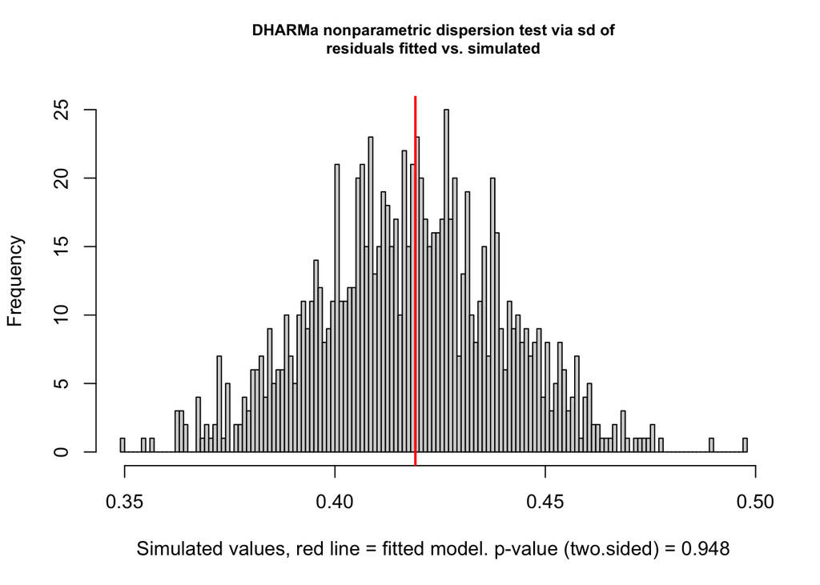

```
##
##  DHARMa nonparametric dispersion test via sd of residuals fitted vs.
##  simulated
##
## data:  simulationOutput
## dispersion = 1.0037, p-value = 0.948
## alternative hypothesis: two.sided
```

```r
# --- PLOT MODEL RESIDUALS --- #

# Simulate residuals from the fitted model

simulationOutput <- simulateResiduals(fittedModel = model,
                                      n = 1000)

# Test for overdispersion in the model to check if variance exceeds mean

testDispersion(simulationOutput)
```

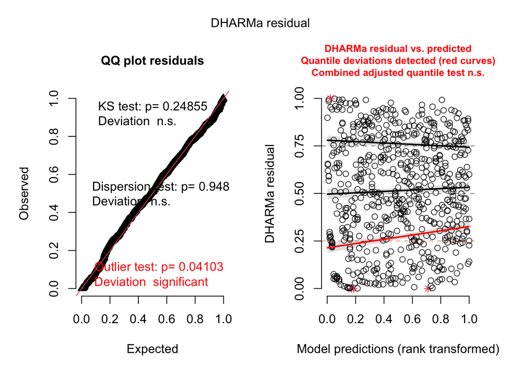

```r
# Plot Q-Q and Residuals vs Fitted plots

plot(simulationOutput)
```

### Biomass

```r
response_variable_selected = "bioarea_mm2_per_ml"
```

**Plot original data**

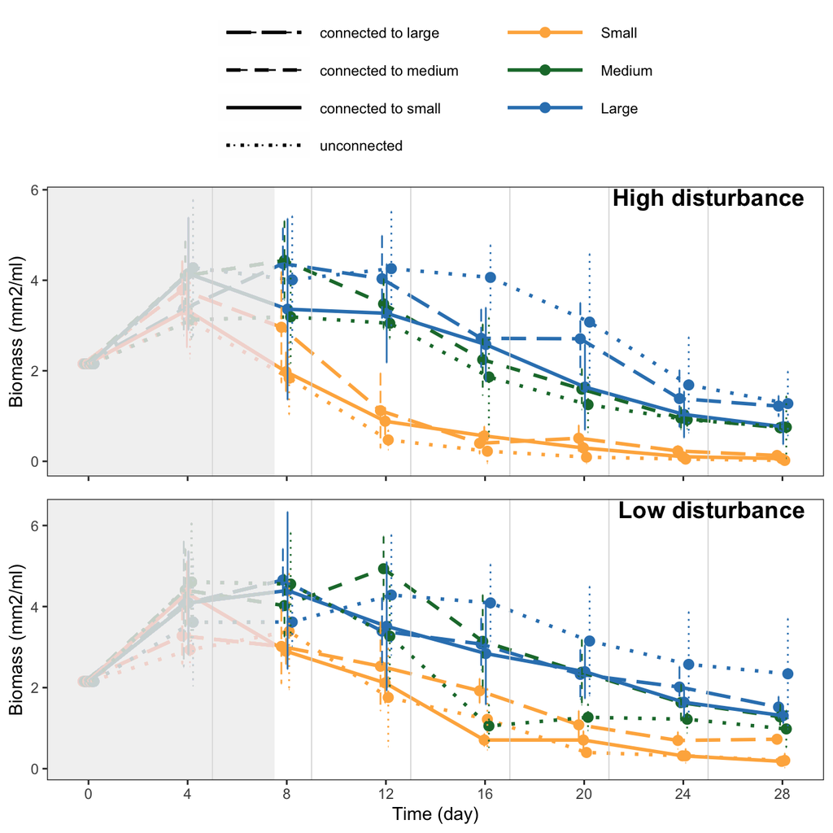

```r
# --- ORIGINAL DATA - PLOT MEAN ± 95% CI --- #

p1 = plot.all.patches.points(data = ds_ecosystems %>%
                               filter(disturbance == "high"),
                             response_variable_selected) +
  annotate("text",
           x = Inf,
           y = Inf,
           label = "High disturbance",
           hjust = 1.1,
           vjust = 1.1,
           size = 5,
           fontface = "bold") + # Adjust position and style
  theme(axis.title.x = element_blank(),  # Remove x-axis title
        axis.text.x = element_blank())  # Remove x-axis text

p2 = plot.all.patches.points(data = ds_ecosystems %>%
                               filter(disturbance == "low"),
                             response_variable_selected) +
  theme(legend.position = "none") +
  annotate("text",
           x = Inf,
           y = Inf,
           label = "Low disturbance",
           hjust = 1.1,
           vjust = 1.1,
           size = 5,
           fontface = "bold") # Adjust position and style

# Arrange the plots vertically

ggarrange(p1,
          p2,
          ncol = 1,
          nrow = 2,
          heights = c(1, 0.7))
```

**Prepare data for analysis**

```r
# --- PREPARE DATA FOR ANALYSIS --- #

# Add baselines

baselines = ds_ecosystems %>%
  filter(time_point == time_point_of_baselines) %>%
  select(ecosystem_ID,
         all_of(response_variable_selected)) %>%
  rename(baseline = all_of(response_variable_selected))

data_for_analysis = ds_ecosystems %>%
  left_join(baselines)

# Filter data and change level names

data_for_analysis = data_for_analysis %>%
  filter(time_point %in% time_points_model,
         #!is.na(water_addition_ml),
         !is.na(!!sym(response_variable_selected)),
         !is.infinite(!!sym(response_variable_selected))) %>%
  mutate(ecosystem_type = case_when(ecosystem_type == "Small unconnected" ~ "S",
                                    ecosystem_type == "Medium unconnected" ~ "M",
                                    ecosystem_type == "Large unconnected" ~ "L",
                                    ecosystem_type == "Small connected to small" ~ "S_S",
                                    ecosystem_type == "Small connected to large" ~ "S_L",
                                    ecosystem_type == "Medium connected to medium" ~ "M_M",
                                    ecosystem_type == "Large connected to large" ~ "L_L",
                                    ecosystem_type == "Large connected to small" ~ "L_S",
                                    TRUE ~ ecosystem_type)) %>%
  ungroup()
```

**Plot data for analysis means**

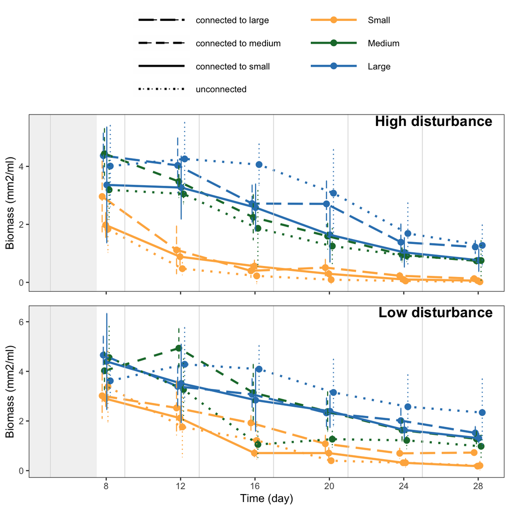

```r
# --- DATA FOR ANALYSIS - PLOT MEAN ± 95% CI --- #

p1 = plot.all.patches.points(data = data_for_analysis %>%
                               filter(disturbance == "high"),
                             response_variable_selected) +
  annotate("text",
           x = Inf,
           y = Inf,
           label = "High disturbance",
           hjust = 1.1,
           vjust = 1.1,
           size = 5,
           fontface = "bold") + # Adjust position and style
  theme(axis.title.x = element_blank(),  # Remove x-axis title
        axis.text.x = element_blank())  # Remove x-axis text

p2 = plot.all.patches.points(data = data_for_analysis %>%
                               filter(disturbance == "low"),
                             response_variable_selected) +
  theme(legend.position = "none") +
  annotate("text",
           x = Inf,
           y = Inf,
           label = "Low disturbance",
           hjust = 1.1,
           vjust = 1.1,
           size = 5,
           fontface = "bold") # Adjust position and style

# Arrange the plots vertically

ggarrange(p1,
          p2,
          ncol = 1,
          nrow = 2,
          heights = c(1, 0.7))
```

**Compute model results**

```r
# --- MODEL - CONSTRUCT --- #

# Define formula

formula = paste("get(response_variable_selected) ~",
                "ecosystem_type * disturbance * day +",
                "(day | ecosystem_ID) +",
                "(day | baseline)") %>%
  print()
```

```
## [1] "get(response_variable_selected) ~ ecosystem_type * disturbance * day + (day | ecosystem_ID) + (day | baseline)"
```

```r
# Construct model

model = try.different.optimizers.ecos(data_for_analysis,
                                      formula)
```

```
## [1] "Model successfully fitted with optimizer: bobyqa "
```

```r
# --- MODEL - SUMMARY --- #

print(summary(model), digits = 1)
```

```
## Linear mixed model fit by maximum likelihood . t-tests use Satterthwaite's
##   method [lmerModLmerTest]
## Formula: formula
##    Data: data
## Control: lmerControl(optimizer = opt$optimizer)
##
##       AIC       BIC    logLik -2*log(L)  df.resid
##    1639.4    1814.3    -780.7    1561.4       615
##
## Scaled residuals:
##    Min     1Q Median     3Q    Max
##   -3.1   -0.6    0.0    0.5    3.6
##
## Random effects:
##  Groups       Name        Variance Std.Dev. Corr
##  ecosystem_ID (Intercept) 8e-02    0.29
##               day         1e-04    0.01     -1.00
##  baseline     (Intercept) 2e-01    0.43
##               day         2e-04    0.02     -1.00
##  Residual                 6e-01    0.77
## Number of obs: 654, groups:  ecosystem_ID, 109; baseline, 109
##
## Fixed effects:
##                                      Estimate Std. Error     df t value
## (Intercept)                              5.94       0.46 122.57    12.9
## ecosystem_typeL_L                       -0.15       0.56 122.57    -0.3
## ecosystem_typeL_S                       -1.18       0.65 122.57    -1.8
## ecosystem_typeM                         -1.63       0.65 122.57    -2.5
## ecosystem_typeM_M                       -0.26       0.56 122.57    -0.5
## ecosystem_typeS                         -4.14       0.69 122.57    -6.0
## ecosystem_typeS_L                       -2.90       0.65 122.57    -4.5
## ecosystem_typeS_S                       -3.72       0.56 122.57    -6.6
## disturbancelow                          -0.99       0.65 122.57    -1.5
## day                                     -0.16       0.02 167.68    -7.2
## ecosystem_typeL_L:disturbancelow         0.68       0.80 122.57     0.9
## ecosystem_typeL_S:disturbancelow         1.68       0.92 122.57     1.8
## ecosystem_typeM:disturbancelow           1.80       0.92 122.57     2.0
## ecosystem_typeM_M:disturbancelow         1.35       0.80 122.57     1.7
## ecosystem_typeS:disturbancelow           3.12       0.95 122.57     3.3
## ecosystem_typeS_L:disturbancelow         1.90       0.92 122.57     2.1
```

[output cut: 36 more lines]

```
## ecosystem_typeM:day                     0.474
## ecosystem_typeM_M:day                   0.258
## ecosystem_typeS:day                     0.012 *
## ecosystem_typeS_L:day                   0.203
## ecosystem_typeS_S:day                   0.009 **
## disturbancelow:day                      0.026 *
## ecosystem_typeL_L:disturbancelow:day    0.213
## ecosystem_typeL_S:disturbancelow:day    0.086 .
## ecosystem_typeM:disturbancelow:day      0.021 *
## ecosystem_typeM_M:disturbancelow:day    0.163
## ecosystem_typeS:disturbancelow:day      0.002 **
## ecosystem_typeS_L:disturbancelow:day    0.081 .
## ecosystem_typeS_S:disturbancelow:day    0.002 **
## ---
## Signif. codes:  0 '***' 0.001 '**' 0.01 '*' 0.05 '.' 0.1 ' ' 1
```

```
## optimizer (bobyqa) convergence code: 0 (OK)
## boundary (singular) fit: see help('isSingular')
```

```r
# --- MODEL - ANOVA --- #

car::Anova(model, type = "III")
```

```
## Analysis of Deviance Table (Type III Wald chisquare tests)
##
## Response: get(response_variable_selected)
##                                   Chisq Df Pr(>Chisq)
## (Intercept)                    166.6826  1  < 2.2e-16 ***
## ecosystem_type                 124.6138  7  < 2.2e-16 ***
## disturbance                      2.3252  1    0.12729
## day                             51.2281  1  8.223e-13 ***
## ecosystem_type:disturbance      18.2610  7    0.01085 *
## ecosystem_type:day              33.5307  7  2.108e-05 ***
## disturbance:day                  5.0218  1    0.02503 *
## ecosystem_type:disturbance:day  17.2032  7    0.01613 *
## ---
## Signif. codes:  0 '***' 0.001 '**' 0.01 '*' 0.05 '.' 0.1 ' ' 1
```

```r
# --- ESTIMATE MARGINAL MEANS --- #

emmeans_output = emmeans(model,
                         specs = ~ ecosystem_type * disturbance * day,
                         adjust = "sidak",
                         bias.adj = TRUE,
                         lmer.df = "satterthwaite")

emmeans_output
```

```
##  ecosystem_type disturbance day emmean    SE  df lower.CL upper.CL
##  L              high         18  3.061 0.161 127    2.576    3.547
##  L_L            high         18  2.739 0.114 127    2.396    3.082
##  L_S            high         18  2.108 0.161 127    1.623    2.593
##  M              high         18  1.838 0.161 127    1.352    2.323
##  M_M            high         18  2.241 0.114 127    1.898    2.584
##  S              high         18  0.448 0.181 127   -0.094    0.991
##  S_L            high         18  0.891 0.161 127    0.406    1.376
##  S_S            high         18  0.647 0.114 127    0.304    0.990
##  L              low          18  3.343 0.161 127    2.858    3.828
##  L_L            low          18  2.831 0.114 127    2.488    3.174
##  L_S            low          18  2.682 0.161 127    2.196    3.167
##  M              low          18  2.057 0.161 127    1.572    2.543
##  M_M            low          18  2.898 0.114 127    2.555    3.242
##  S              low          18  1.214 0.161 127    0.728    1.699
##  S_L            low          18  1.662 0.161 127    1.176    2.147
##  S_S            low          18  1.154 0.114 127    0.811    1.497
##
## Degrees-of-freedom method: satterthwaite
## Results are given on the get (not the response) scale.
## Confidence level used: 0.95
## Conf-level adjustment: sidak method for 16 estimates
```

```r
# --- CODE EACH LEVEL OF DISTURBANCE AND ECOSYSTEM TYPE TO THEN PRODUCE CONTRASTS --- #

high_L = c(1, rep(0,15))
high_L_L = c(rep(0,1), 1, rep(0,14))
high_L_S = c(rep(0,2), 1, rep(0,13))
high_M = c(rep(0,3), 1, rep(0,12))
high_M_M = c(rep(0,4), 1, rep(0,11))
high_S = c(rep(0,5), 1, rep(0,10))
high_S_L = c(rep(0,6), 1, rep(0,9))
high_S_S = c(rep(0,7), 1, rep(0,8))
low_L = c(rep(0,8), 1, rep(0,7))
low_L_L = c(rep(0,9), 1, rep(0,6))
low_L_S = c(rep(0,10), 1, rep(0,5))
low_M = c(rep(0,11), 1, rep(0,4))
low_M_M = c(rep(0,12), 1, rep(0,3))
low_S = c(rep(0,13), 1, rep(0,2))
low_S_L = c(rep(0,14), 1, rep(0,1))
low_S_S = c(rep(0,15), 1)
```

```r
# --- PRODUCE ECOSYSTEM TYPE CONTRASTS --- #

# Set parameters

n_of_digits = 3

# Compute constrasts

contrasts = contrast(emmeans_output,
                     method = list("high S_L - S" = high_S_L - high_S,
                                   "high S_L - S_S" = high_S_L - high_S_S,
                                   "high S_S - S" = high_S_S - high_S,
                                   "high M_M - M" = high_M_M - high_M,
                                   "high L_S - L" = high_L_S - high_L,
                                   "high L_S - L_L" = high_L_S - high_L_L,
                                   "high L_L - L" = high_L_L - high_L,
                                   "low S_L - S" = low_S_L - low_S,
                                   "low S_L - S_S" = low_S_L - low_S_S,
                                   "low S_S - S" = low_S_S - low_S,
                                   "low M_M - M" = low_M_M - low_M,
                                   "low L_S - L" = low_L_S - low_L,
                                   "low L_S - L_L" = low_L_S - low_L_L,
                                   "low L_L - L" = low_L_L - low_L)) %>%
  as.data.frame() %>%
  mutate(p.value = round(p.value, digits = n_of_digits),
         estimate = round(estimate, digits = n_of_digits),
         SE = round(SE, digits = n_of_digits),
         df = round(df, digits = n_of_digits),
         t.ratio = round(t.ratio, digits = n_of_digits),
         e = "",
         e = ifelse(p.value > 0.1,
                           "",
                           e),
         e = ifelse(p.value < 0.05,
                           "*",
                           e),
         e = ifelse(p.value < 0.01,
                           "**",
                           e),
         e = ifelse(p.value < 0.001,
                           "***",
                           e)) %>%
  rename(" " = e)
```

**Show results**

```r
# --- SHOW ECOSYSTEM TYPE CONSTRASTS --- #

contrasts
```

```
##          contrast estimate    SE      df t.ratio p.value
## 1    high S_L - S    0.442 0.242 126.838   1.826   0.070
## 2  high S_L - S_S    0.244 0.198 126.838   1.233   0.220
## 3    high S_S - S    0.199 0.214 126.838   0.930   0.354
## 4    high M_M - M    0.404 0.198 126.838   2.041   0.043   *
## 5    high L_S - L   -0.953 0.228 126.838  -4.175   0.000 ***
## 6  high L_S - L_L   -0.631 0.198 126.838  -3.190   0.002  **
## 7    high L_L - L   -0.322 0.198 126.838  -1.631   0.105
## 8     low S_L - S    0.448 0.228 126.838   1.962   0.052
## 9   low S_L - S_S    0.507 0.198 126.838   2.565   0.011   *
## 10    low S_S - S   -0.059 0.198 126.838  -0.300   0.765
## 11    low M_M - M    0.841 0.198 126.838   4.253   0.000 ***
## 12    low L_S - L   -0.662 0.228 126.838  -2.897   0.004  **
## 13  low L_S - L_L   -0.149 0.198 126.838  -0.755   0.452
## 14    low L_L - L   -0.512 0.198 126.838  -2.591   0.011   *
```

**Show model residuals residuals**

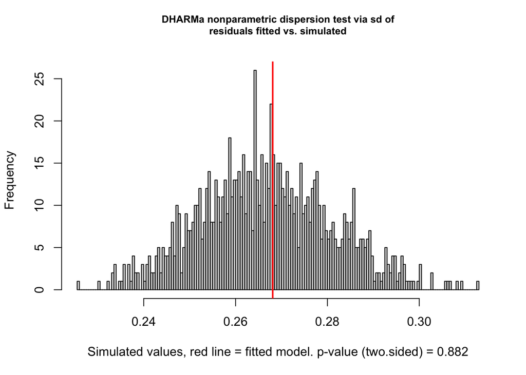

```
##
##  DHARMa nonparametric dispersion test via sd of residuals fitted vs.
##  simulated
##
## data:  simulationOutput
## dispersion = 1.0053, p-value = 0.882
## alternative hypothesis: two.sided
```

```r
# --- PLOT MODEL RESIDUALS --- #

# Simulate residuals from the fitted model

simulationOutput <- simulateResiduals(fittedModel = model,
                                      n = 1000)

# Test for overdispersion in the model to check if variance exceeds mean

testDispersion(simulationOutput)
```

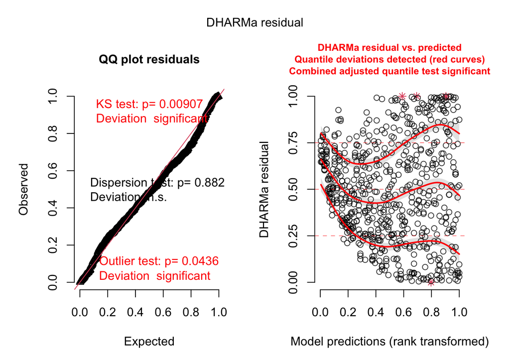

```r
# Plot Q-Q and Residuals vs Fitted plots

plot(simulationOutput)
```

### Richness

```r
response_variable_selected = "species_richness"
```

**Plot original data**

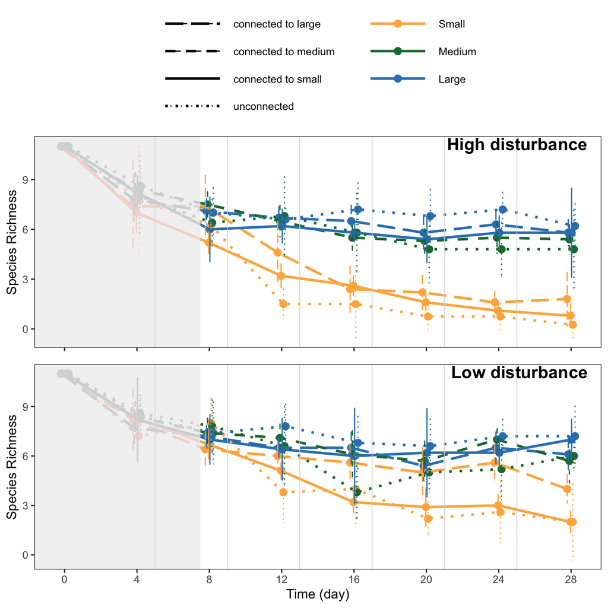

```r
# --- ORIGINAL DATA - PLOT MEAN ± 95% CI --- #

p1 = plot.all.patches.points(data = ds_ecosystems %>%
                               filter(disturbance == "high"),
                             response_variable_selected) +
  annotate("text",
           x = Inf,
           y = Inf,
           label = "High disturbance",
           hjust = 1.1,
           vjust = 1.1,
           size = 5,
           fontface = "bold") + # Adjust position and style
  theme(axis.title.x = element_blank(),  # Remove x-axis title
        axis.text.x = element_blank())  # Remove x-axis text

p2 = plot.all.patches.points(data = ds_ecosystems %>%
                               filter(disturbance == "low"),
                             response_variable_selected) +
  theme(legend.position = "none") +
  annotate("text",
           x = Inf,
           y = Inf,
           label = "Low disturbance",
           hjust = 1.1,
           vjust = 1.1,
           size = 5,
           fontface = "bold") # Adjust position and style

# Arrange the plots vertically

ggarrange(p1,
          p2,
          ncol = 1,
          nrow = 2,
          heights = c(1, 0.7))
```

**Prepare data for analysis**

```r
# --- PREPARE DATA FOR ANALYSIS --- #

# Add baselines

baselines = ds_ecosystems %>%
  filter(time_point == time_point_of_baselines) %>%
  select(ecosystem_ID,
         all_of(response_variable_selected)) %>%
  rename(baseline = all_of(response_variable_selected))

data_for_analysis = ds_ecosystems %>%
  left_join(baselines)

# Filter data and change level names

data_for_analysis = data_for_analysis %>%
  filter(time_point %in% time_points_model,
         #!is.na(water_addition_ml),
         !is.na(!!sym(response_variable_selected)),
         !is.infinite(!!sym(response_variable_selected))) %>%
  mutate(ecosystem_type = case_when(ecosystem_type == "Small unconnected" ~ "S",
                                    ecosystem_type == "Medium unconnected" ~ "M",
                                    ecosystem_type == "Large unconnected" ~ "L",
                                    ecosystem_type == "Small connected to small" ~ "S_S",
                                    ecosystem_type == "Small connected to large" ~ "S_L",
                                    ecosystem_type == "Medium connected to medium" ~ "M_M",
                                    ecosystem_type == "Large connected to large" ~ "L_L",
                                    ecosystem_type == "Large connected to small" ~ "L_S",
                                    TRUE ~ ecosystem_type)) %>%
  ungroup()
```

**Plot data for analysis means**

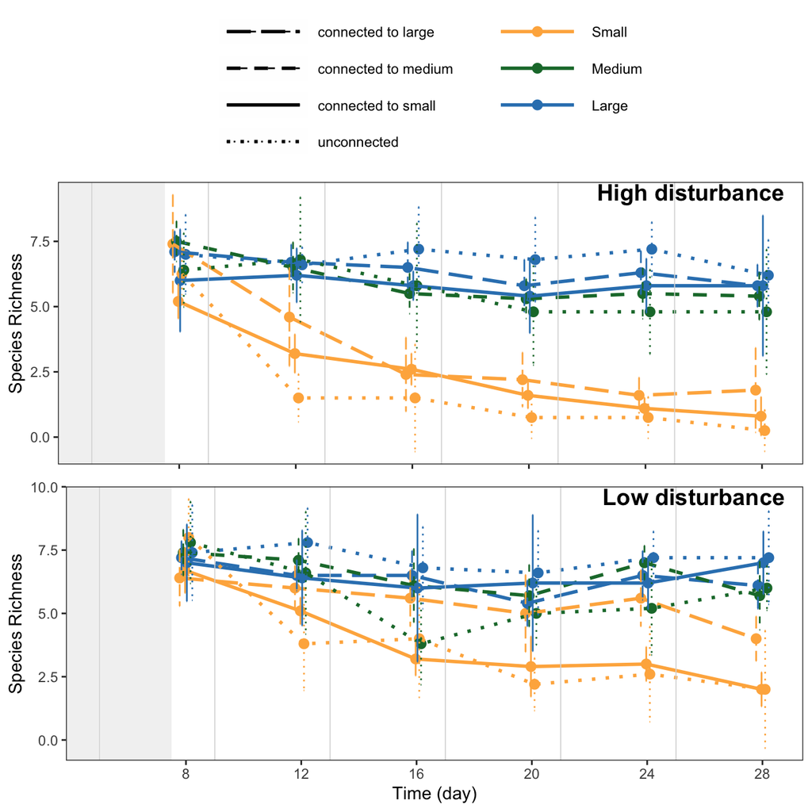

```r
# --- DATA FOR ANALYSIS - PLOT MEAN ± 95% CI --- #

p1 = plot.all.patches.points(data = data_for_analysis %>%
                               filter(disturbance == "high"),
                             response_variable_selected) +
  annotate("text",
           x = Inf,
           y = Inf,
           label = "High disturbance",
           hjust = 1.1,
           vjust = 1.1,
           size = 5,
           fontface = "bold") + # Adjust position and style
  theme(axis.title.x = element_blank(),  # Remove x-axis title
        axis.text.x = element_blank())  # Remove x-axis text

p2 = plot.all.patches.points(data = data_for_analysis %>%
                               filter(disturbance == "low"),
                             response_variable_selected) +
  theme(legend.position = "none") +
  annotate("text",
           x = Inf,
           y = Inf,
           label = "Low disturbance",
           hjust = 1.1,
           vjust = 1.1,
           size = 5,
           fontface = "bold") # Adjust position and style

# Arrange the plots vertically

ggarrange(p1,
          p2,
          ncol = 1,
          nrow = 2,
          heights = c(1, 0.7))
```

**Compute model results**

```r
# --- MODEL - CONSTRUCT --- #

# Define formula

formula = paste("get(response_variable_selected) ~",
                "ecosystem_type * disturbance * day +",
                "(day | ecosystem_ID) +",
                "(day | baseline)") %>%
  print()
```

```
## [1] "get(response_variable_selected) ~ ecosystem_type * disturbance * day + (day | ecosystem_ID) + (day | baseline)"
```

```r
# Construct model

model = try.different.optimizers.ecos(data_for_analysis,
                                      formula)
```

```
## [1] "Model successfully fitted with optimizer: bobyqa "
```

```r
# --- MODEL - SUMMARY --- #

print(summary(model), digits = 1)
```

```
## Linear mixed model fit by maximum likelihood . t-tests use Satterthwaite's
##   method [lmerModLmerTest]
## Formula: formula
##    Data: data
## Control: lmerControl(optimizer = opt$optimizer)
##
##       AIC       BIC    logLik -2*log(L)  df.resid
##    2273.8    2448.7   -1097.9    2195.8       615
##
## Scaled residuals:
##    Min     1Q Median     3Q    Max
##   -3.6   -0.6    0.0    0.6    3.2
##
## Random effects:
##  Groups       Name        Variance Std.Dev. Corr
##  ecosystem_ID (Intercept) 7e-05    0.008
##               day         9e-06    0.003    -1.00
##  baseline     (Intercept) 1e-01    0.321
##               day         7e-05    0.009    -1.00
##  Residual                 2e+00    1.289
## Number of obs: 654, groups:  ecosystem_ID, 109; baseline, 8
##
## Fixed effects:
##                                      Estimate Std. Error     df t value
## (Intercept)                             7e+00      7e-01  3e+02    10.5
## ecosystem_typeL_L                       3e-01      8e-01  5e+02     0.4
## ecosystem_typeL_S                      -8e-01      9e-01  5e+02    -0.9
## ecosystem_typeM                         3e-01      9e-01  5e+02     0.4
## ecosystem_typeM_M                       5e-01      8e-01  5e+02     0.6
## ecosystem_typeS                        -1e+00      1e+00  5e+02    -1.2
## ecosystem_typeS_L                       1e+00      9e-01  5e+02     1.0
## ecosystem_typeS_S                      -9e-01      8e-01  5e+02    -1.1
## disturbancelow                          5e-01      9e-01  5e+02     0.6
## day                                    -2e-02      3e-02  5e+02    -0.5
## ecosystem_typeL_L:disturbancelow       -8e-01      1e+00  5e+02    -0.7
## ecosystem_typeL_S:disturbancelow       -5e-01      1e+00  5e+02    -0.4
## ecosystem_typeM:disturbancelow         -6e-01      1e+00  5e+02    -0.5
## ecosystem_typeM_M:disturbancelow       -5e-01      1e+00  5e+02    -0.5
## ecosystem_typeS:disturbancelow          2e+00      1e+00  5e+02     1.5
## ecosystem_typeS_L:disturbancelow       -1e+00      1e+00  5e+02    -1.1
```

[output cut: 36 more lines]

```
## ecosystem_typeM:day                      0.07 .
## ecosystem_typeM_M:day                    0.06 .
## ecosystem_typeS:day                     4e-05 ***
## ecosystem_typeS_L:day                   5e-07 ***
## ecosystem_typeS_S:day                   7e-06 ***
## disturbancelow:day                       0.89
## ecosystem_typeL_L:disturbancelow:day     0.73
## ecosystem_typeL_S:disturbancelow:day     0.65
## ecosystem_typeM:disturbancelow:day       0.72
## ecosystem_typeM_M:disturbancelow:day     0.52
## ecosystem_typeS:disturbancelow:day       0.80
## ecosystem_typeS_L:disturbancelow:day     0.01 *
## ecosystem_typeS_S:disturbancelow:day     0.99
## ---
## Signif. codes:  0 '***' 0.001 '**' 0.01 '*' 0.05 '.' 0.1 ' ' 1
```

```
## optimizer (bobyqa) convergence code: 0 (OK)
## boundary (singular) fit: see help('isSingular')
```

```r
# --- MODEL - ANOVA --- #

car::Anova(model, type = "III")
```

```
## Analysis of Deviance Table (Type III Wald chisquare tests)
##
## Response: get(response_variable_selected)
##                                   Chisq Df Pr(>Chisq)
## (Intercept)                    110.2652  1  < 2.2e-16 ***
## ecosystem_type                  11.8520  7     0.1055
## disturbance                      0.3227  1     0.5700
## day                              0.2915  1     0.5893
## ecosystem_type:disturbance      11.0534  7     0.1363
## ecosystem_type:day              63.3873  7  3.169e-11 ***
## disturbance:day                  0.0199  1     0.8879
## ecosystem_type:disturbance:day  10.9138  7     0.1424
## ---
## Signif. codes:  0 '***' 0.001 '**' 0.01 '*' 0.05 '.' 0.1 ' ' 1
```

```r
# --- ESTIMATE MARGINAL MEANS --- #

emmeans_output = emmeans(model,
                         specs = ~ ecosystem_type * disturbance * day,
                         adjust = "sidak",
                         bias.adj = TRUE,
                         lmer.df = "satterthwaite")

emmeans_output
```

```
##  ecosystem_type disturbance day emmean    SE    df lower.CL upper.CL
##  L              high         18   6.84 0.251 115.8    6.081     7.59
##  L_L            high         18   6.40 0.181  77.8    5.845     6.95
##  L_S            high         18   5.92 0.250 117.0    5.168     6.67
##  M              high         18   5.58 0.248 124.7    4.835     6.32
##  M_M            high         18   5.94 0.183  69.6    5.381     6.50
##  S              high         18   1.78 0.277 128.9    0.948     2.61
##  S_L            high         18   3.34 0.248 125.3    2.596     4.09
##  S_S            high         18   2.46 0.182  75.4    1.902     3.01
##  L              low          18   7.25 0.252 114.4    6.492     8.01
##  L_L            low          18   6.38 0.182  74.8    5.826     6.94
##  L_S            low          18   6.38 0.250 115.4    5.621     7.13
##  M              low          18   5.81 0.255 108.3    5.042     6.58
##  M_M            low          18   6.51 0.183  69.1    5.947     7.06
##  S              low          18   3.87 0.250 117.8    3.119     4.62
##  S_L            low          18   5.42 0.249 120.3    4.674     6.17
##  S_S            low          18   3.86 0.187  64.8    3.292     4.44
##
## Degrees-of-freedom method: satterthwaite
## Results are given on the get (not the response) scale.
## Confidence level used: 0.95
## Conf-level adjustment: sidak method for 16 estimates
```

```r
# --- CODE EACH LEVEL OF DISTURBANCE AND ECOSYSTEM TYPE TO THEN PRODUCE CONTRASTS --- #

high_L = c(1, rep(0,15))
high_L_L = c(rep(0,1), 1, rep(0,14))
high_L_S = c(rep(0,2), 1, rep(0,13))
high_M = c(rep(0,3), 1, rep(0,12))
high_M_M = c(rep(0,4), 1, rep(0,11))
high_S = c(rep(0,5), 1, rep(0,10))
high_S_L = c(rep(0,6), 1, rep(0,9))
high_S_S = c(rep(0,7), 1, rep(0,8))
low_L = c(rep(0,8), 1, rep(0,7))
low_L_L = c(rep(0,9), 1, rep(0,6))
low_L_S = c(rep(0,10), 1, rep(0,5))
low_M = c(rep(0,11), 1, rep(0,4))
low_M_M = c(rep(0,12), 1, rep(0,3))
low_S = c(rep(0,13), 1, rep(0,2))
low_S_L = c(rep(0,14), 1, rep(0,1))
low_S_S = c(rep(0,15), 1)
```

```r
# --- PRODUCE ECOSYSTEM TYPE CONTRASTS --- #

# Set parameters

n_of_digits = 3

# Compute constrasts

contrasts = contrast(emmeans_output,
                     method = list("high S_L - S" = high_S_L - high_S,
                                   "high S_L - S_S" = high_S_L - high_S_S,
                                   "high S_S - S" = high_S_S - high_S,
                                   "high M_M - M" = high_M_M - high_M,
                                   "high L_S - L" = high_L_S - high_L,
                                   "high L_S - L_L" = high_L_S - high_L_L,
                                   "high L_L - L" = high_L_L - high_L,
                                   "low S_L - S" = low_S_L - low_S,
                                   "low S_L - S_S" = low_S_L - low_S_S,
                                   "low S_S - S" = low_S_S - low_S,
                                   "low M_M - M" = low_M_M - low_M,
                                   "low L_S - L" = low_L_S - low_L,
                                   "low L_S - L_L" = low_L_S - low_L_L,
                                   "low L_L - L" = low_L_L - low_L)) %>%
  as.data.frame() %>%
  mutate(p.value = round(p.value, digits = n_of_digits),
         estimate = round(estimate, digits = n_of_digits),
         SE = round(SE, digits = n_of_digits),
         df = round(df, digits = n_of_digits),
         t.ratio = round(t.ratio, digits = n_of_digits),
         e = "",
         e = ifelse(p.value > 0.1,
                           "",
                           e),
         e = ifelse(p.value < 0.05,
                           "*",
                           e),
         e = ifelse(p.value < 0.01,
                           "**",
                           e),
         e = ifelse(p.value < 0.001,
                           "***",
                           e)) %>%
  rename(" " = e)
```

**Show results**

```r
# --- SHOW ECOSYSTEM TYPE CONSTRASTS --- #

contrasts
```

```
##          contrast estimate    SE      df t.ratio p.value
## 1    high S_L - S    1.560 0.363 156.151   4.300   0.000 ***
## 2  high S_L - S_S    0.886 0.293 154.359   3.021   0.003  **
## 3    high S_S - S    0.674 0.316 153.875   2.133   0.035   *
## 4    high M_M - M    0.359 0.293 154.280   1.225   0.222
## 5    high L_S - L   -0.916 0.336 152.002  -2.723   0.007  **
## 6  high L_S - L_L   -0.474 0.294 155.021  -1.614   0.109
## 7    high L_L - L   -0.442 0.295 155.707  -1.498   0.136
## 8     low S_L - S    1.550 0.338 153.598   4.587   0.000 ***
## 9   low S_L - S_S    1.557 0.291 151.772   5.348   0.000 ***
## 10    low S_S - S   -0.007 0.293 154.140  -0.024   0.981
## 11    low M_M - M    0.694 0.295 155.647   2.350   0.020   *
## 12    low L_S - L   -0.874 0.343 156.502  -2.551   0.012   *
## 13  low L_S - L_L   -0.006 0.294 155.262  -0.021   0.983
## 14    low L_L - L   -0.868 0.294 155.249  -2.949   0.004  **
```

**Show model residuals residuals**

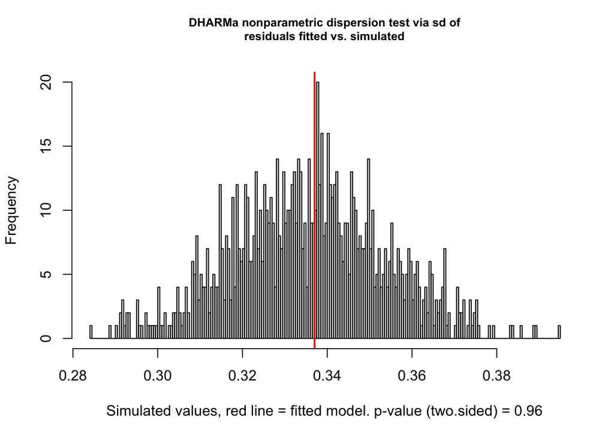

```
##
##  DHARMa nonparametric dispersion test via sd of residuals fitted vs.
##  simulated
##
## data:  simulationOutput
## dispersion = 1.004, p-value = 0.96
## alternative hypothesis: two.sided
```

```r
# --- PLOT MODEL RESIDUALS --- #

# Simulate residuals from the fitted model

simulationOutput <- simulateResiduals(fittedModel = model,
                                      n = 1000)

# Test for overdispersion in the model to check if variance exceeds mean

testDispersion(simulationOutput)
```

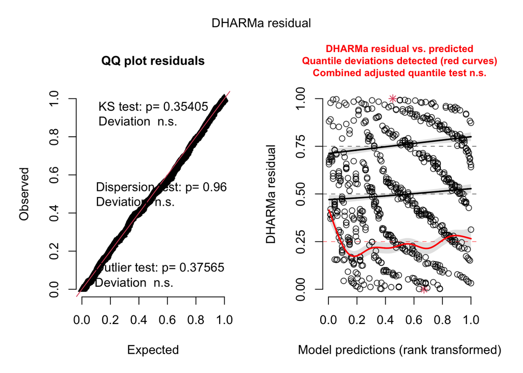

```r
# Plot Q-Q and Residuals vs Fitted plots

plot(simulationOutput)
```

### Evenness

```r
response_variable_selected = "evenness_pielou"
```

**Plot original data**

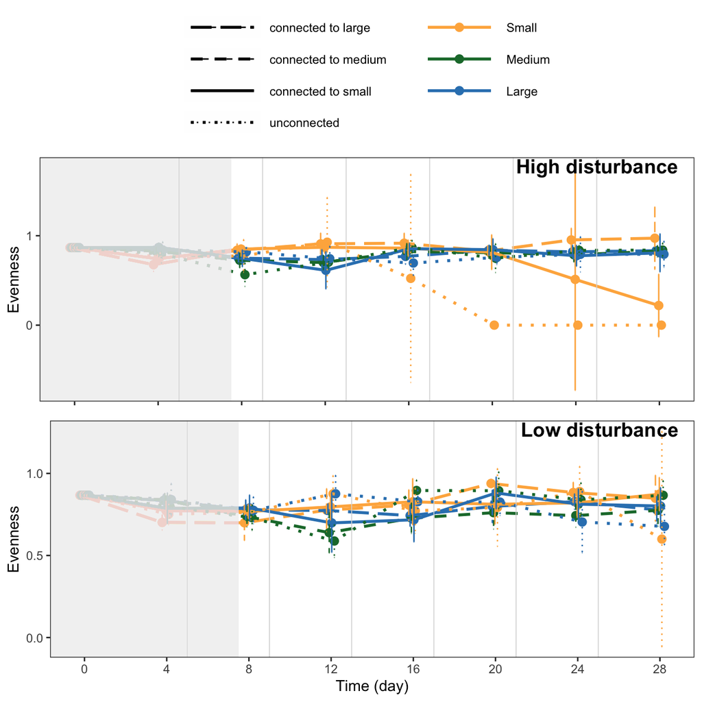

```r
# --- ORIGINAL DATA - PLOT MEAN ± 95% CI --- #

p1 = plot.all.patches.points(data = ds_ecosystems %>%
                               filter(disturbance == "high"),
                             response_variable_selected) +
  annotate("text",
           x = Inf,
           y = Inf,
           label = "High disturbance",
           hjust = 1.1,
           vjust = 1.1,
           size = 5,
           fontface = "bold") + # Adjust position and style
  theme(axis.title.x = element_blank(),  # Remove x-axis title
        axis.text.x = element_blank())  # Remove x-axis text
p2 = plot.all.patches.points(data = ds_ecosystems %>%
                               filter(disturbance == "low"),
                             response_variable_selected) +
  theme(legend.position = "none") +
  annotate("text",
           x = Inf,
           y = Inf,
           label = "Low disturbance",
           hjust = 1.1,
           vjust = 1.1,
           size = 5,
           fontface = "bold") # Adjust position and style

# Arrange the plots vertically

ggarrange(p1,
          p2,
          ncol = 1,
          nrow = 2,
          heights = c(1, 0.7))
```

**Prepare data for analysis**

```r
# --- PREPARE DATA FOR ANALYSIS --- #

# Add baselines

baselines = ds_ecosystems %>%
  filter(time_point == time_point_of_baselines) %>%
  select(ecosystem_ID,
         all_of(response_variable_selected)) %>%
  rename(baseline = all_of(response_variable_selected))

data_for_analysis = ds_ecosystems %>%
  left_join(baselines)

# Filter data and change level names

data_for_analysis = data_for_analysis %>%
  filter(time_point %in% time_points_model,
         #!is.na(water_addition_ml),
         !is.na(!!sym(response_variable_selected)),
         !is.infinite(!!sym(response_variable_selected))) %>%
  mutate(ecosystem_type = case_when(ecosystem_type == "Small unconnected" ~ "S",
                                    ecosystem_type == "Medium unconnected" ~ "M",
                                    ecosystem_type == "Large unconnected" ~ "L",
                                    ecosystem_type == "Small connected to small" ~ "S_S",
                                    ecosystem_type == "Small connected to large" ~ "S_L",
                                    ecosystem_type == "Medium connected to medium" ~ "M_M",
                                    ecosystem_type == "Large connected to large" ~ "L_L",
                                    ecosystem_type == "Large connected to small" ~ "L_S",
                                    TRUE ~ ecosystem_type)) %>%
  ungroup()
```

**Plot data for analysis means**

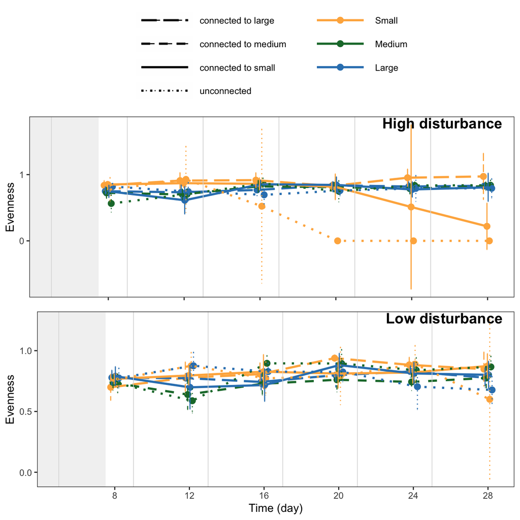

```r
# --- DATA FOR ANALYSIS - PLOT MEAN ± 95% CI --- #

p1 = plot.all.patches.points(data = data_for_analysis %>%
                               filter(disturbance == "high"),
                             response_variable_selected) +
  annotate("text",
           x = Inf,
           y = Inf,
           label = "High disturbance",
           hjust = 1.1,
           vjust = 1.1,
           size = 5,
           fontface = "bold") + # Adjust position and style
  theme(axis.title.x = element_blank(),  # Remove x-axis title
        axis.text.x = element_blank())  # Remove x-axis text
p2 = plot.all.patches.points(data = data_for_analysis %>%
                               filter(disturbance == "low"),
                             response_variable_selected) +
  theme(legend.position = "none") +
  annotate("text",
           x = Inf,
           y = Inf,
           label = "Low disturbance",
           hjust = 1.1,
           vjust = 1.1,
           size = 5,
           fontface = "bold") # Adjust position and style

# Arrange the plots vertically

ggarrange(p1,
          p2,
          ncol = 1,
          nrow = 2,
          heights = c(1, 0.7))
```

**Compute model results**

```r
# --- MODEL - CONSTRUCT --- #

# Define formula

formula = paste("get(response_variable_selected) ~",
                "ecosystem_type * disturbance * day +",
                "(day | ecosystem_ID) +",
                "(day | baseline)") %>%
  print()
```

```
## [1] "get(response_variable_selected) ~ ecosystem_type * disturbance * day + (day | ecosystem_ID) + (day | baseline)"
```

```r
# Construct model

model = try.different.optimizers.ecos(data_for_analysis,
                                      formula)
```

```
## [1] "Model successfully fitted with optimizer: bobyqa "
```

```r
# --- MODEL - SUMMARY --- #

print(summary(model), digits = 1)
```

```
## Linear mixed model fit by maximum likelihood . t-tests use Satterthwaite's
##   method [lmerModLmerTest]
## Formula: formula
##    Data: data
## Control: lmerControl(optimizer = opt$optimizer)
##
##       AIC       BIC    logLik -2*log(L)  df.resid
##    -692.0    -519.8     385.0    -770.0       573
##
## Scaled residuals:
##    Min     1Q Median     3Q    Max
##   -5.7   -0.5    0.1    0.6    3.9
##
## Random effects:
##  Groups       Name        Variance Std.Dev. Corr
##  ecosystem_ID (Intercept) 2e-15    5e-08
##               day         2e-17    4e-09    -1.00
##  baseline     (Intercept) 2e-10    2e-05
##               day         9e-13    1e-06    -1.00
##  Residual                 2e-02    1e-01
## Number of obs: 612, groups:  ecosystem_ID, 109; baseline, 109
##
## Fixed effects:
##                                      Estimate Std. Error     df t value
## (Intercept)                             8e-01      7e-02  6e+02    11.4
## ecosystem_typeL_L                      -6e-02      8e-02  6e+02    -0.8
## ecosystem_typeL_S                      -8e-02      9e-02  6e+02    -0.9
## ecosystem_typeM                        -2e-01      9e-02  6e+02    -2.2
## ecosystem_typeM_M                      -8e-02      8e-02  6e+02    -0.9
## ecosystem_typeS                         5e-01      1e-01  6e+02     4.3
## ecosystem_typeS_L                       6e-02      1e-01  6e+02     0.6
## ecosystem_typeS_S                       5e-01      8e-02  6e+02     5.5
## disturbancelow                          2e-01      9e-02  6e+02     1.6
## day                                     5e-04      3e-03  6e+02     0.2
## ecosystem_typeL_L:disturbancelow       -9e-02      1e-01  6e+02    -0.8
## ecosystem_typeL_S:disturbancelow       -1e-01      1e-01  6e+02    -0.9
## ecosystem_typeM:disturbancelow         -8e-02      1e-01  6e+02    -0.6
## ecosystem_typeM_M:disturbancelow       -2e-01      1e-01  6e+02    -1.5
## ecosystem_typeS:disturbancelow         -5e-01      1e-01  6e+02    -3.5
## ecosystem_typeS_L:disturbancelow       -3e-01      1e-01  6e+02    -2.2
```

[output cut: 36 more lines]

```
## ecosystem_typeM:day                      0.02 *
## ecosystem_typeM_M:day                    0.25
## ecosystem_typeS:day                     7e-15 ***
## ecosystem_typeS_L:day                    0.47
## ecosystem_typeS_S:day                   3e-11 ***
## disturbancelow:day                       0.11
## ecosystem_typeL_L:disturbancelow:day     0.50
## ecosystem_typeL_S:disturbancelow:day     0.37
## ecosystem_typeM:disturbancelow:day       0.37
## ecosystem_typeM_M:disturbancelow:day     0.30
## ecosystem_typeS:disturbancelow:day      6e-10 ***
## ecosystem_typeS_L:disturbancelow:day     0.10
## ecosystem_typeS_S:disturbancelow:day    6e-11 ***
## ---
## Signif. codes:  0 '***' 0.001 '**' 0.01 '*' 0.05 '.' 0.1 ' ' 1
```

```
## optimizer (bobyqa) convergence code: 0 (OK)
## boundary (singular) fit: see help('isSingular')
```

```r
# --- MODEL - ANOVA --- #

car::Anova(model, type = "III")
```

```
## Analysis of Deviance Table (Type III Wald chisquare tests)
##
## Response: get(response_variable_selected)
##                                   Chisq Df Pr(>Chisq)
## (Intercept)                    130.1357  1  < 2.2e-16 ***
## ecosystem_type                 121.9831  7  < 2.2e-16 ***
## disturbance                      2.6800  1     0.1016
## day                              0.0240  1     0.8769
## ecosystem_type:disturbance      53.2690  7   3.28e-09 ***
## ecosystem_type:day             225.4252  7  < 2.2e-16 ***
## disturbance:day                  2.5267  1     0.1119
## ecosystem_type:disturbance:day 111.4767  7  < 2.2e-16 ***
## ---
## Signif. codes:  0 '***' 0.001 '**' 0.01 '*' 0.05 '.' 0.1 ' ' 1
```

```r
# --- ESTIMATE MARGINAL MEANS --- #

emmeans_output = emmeans(model,
                         specs = ~ ecosystem_type * disturbance * day,
                         adjust = "sidak",
                         bias.adj = TRUE,
                         lmer.df = "satterthwaite")

emmeans_output
```

```
##  ecosystem_type disturbance  day emmean     SE  df lower.CL upper.CL
##  L              high        17.7  0.767 0.0236 612    0.697    0.836
##  L_L            high        17.7  0.789 0.0167 612    0.739    0.838
##  L_S            high        17.7  0.772 0.0236 612    0.702    0.842
##  M              high        17.7  0.756 0.0236 612    0.687    0.826
##  M_M            high        17.7  0.777 0.0167 612    0.728    0.826
##  S              high        17.7  0.415 0.0349 612    0.312    0.518
##  S_L            high        17.7  0.899 0.0276 612    0.817    0.981
##  S_S            high        17.7  0.687 0.0199 612    0.629    0.746
##  L              low         17.7  0.783 0.0236 612    0.713    0.853
##  L_L            low         17.7  0.783 0.0167 612    0.734    0.832
##  L_S            low         17.7  0.782 0.0236 612    0.712    0.852
##  M              low         17.7  0.799 0.0236 612    0.730    0.869
##  M_M            low         17.7  0.729 0.0167 612    0.680    0.779
##  S              low         17.7  0.783 0.0249 612    0.709    0.856
##  S_L            low         17.7  0.823 0.0236 612    0.753    0.893
##  S_S            low         17.7  0.814 0.0176 612    0.762    0.866
##
## Degrees-of-freedom method: satterthwaite
## Results are given on the get (not the response) scale.
## Confidence level used: 0.95
## Conf-level adjustment: sidak method for 16 estimates
```

```r
# --- CODE EACH LEVEL OF DISTURBANCE AND ECOSYSTEM TYPE TO THEN PRODUCE CONTRASTS --- #

high_L = c(1, rep(0,15))
high_L_L = c(rep(0,1), 1, rep(0,14))
high_L_S = c(rep(0,2), 1, rep(0,13))
high_M = c(rep(0,3), 1, rep(0,12))
high_M_M = c(rep(0,4), 1, rep(0,11))
high_S = c(rep(0,5), 1, rep(0,10))
high_S_L = c(rep(0,6), 1, rep(0,9))
high_S_S = c(rep(0,7), 1, rep(0,8))
low_L = c(rep(0,8), 1, rep(0,7))
low_L_L = c(rep(0,9), 1, rep(0,6))
low_L_S = c(rep(0,10), 1, rep(0,5))
low_M = c(rep(0,11), 1, rep(0,4))
low_M_M = c(rep(0,12), 1, rep(0,3))
low_S = c(rep(0,13), 1, rep(0,2))
low_S_L = c(rep(0,14), 1, rep(0,1))
low_S_S = c(rep(0,15), 1)
```

```r
# --- PRODUCE ECOSYSTEM TYPE CONTRASTS --- #

# Set parameters

n_of_digits = 3

# Compute constrasts

contrasts = contrast(emmeans_output,
                     method = list("high S_L - S" = high_S_L - high_S,
                                   "high S_L - S_S" = high_S_L - high_S_S,
                                   "high S_S - S" = high_S_S - high_S,
                                   "high M_M - M" = high_M_M - high_M,
                                   "high L_S - L" = high_L_S - high_L,
                                   "high L_S - L_L" = high_L_S - high_L_L,
                                   "high L_L - L" = high_L_L - high_L,
                                   "low S_L - S" = low_S_L - low_S,
                                   "low S_L - S_S" = low_S_L - low_S_S,
                                   "low S_S - S" = low_S_S - low_S,
                                   "low M_M - M" = low_M_M - low_M,
                                   "low L_S - L" = low_L_S - low_L,
                                   "low L_S - L_L" = low_L_S - low_L_L,
                                   "low L_L - L" = low_L_L - low_L)) %>%
  as.data.frame() %>%
  mutate(p.value = round(p.value, digits = n_of_digits),
         estimate = round(estimate, digits = n_of_digits),
         SE = round(SE, digits = n_of_digits),
         df = round(df, digits = n_of_digits),
         t.ratio = round(t.ratio, digits = n_of_digits),
         e = "",
         e = ifelse(p.value > 0.1,
                           "",
                           e),
         e = ifelse(p.value < 0.05,
                           "*",
                           e),
         e = ifelse(p.value < 0.01,
                           "**",
                           e),
         e = ifelse(p.value < 0.001,
                           "***",
                           e)) %>%
  rename(" " = e)
```

**Show results**

```r
# --- SHOW ECOSYSTEM TYPE CONSTRASTS --- #

contrasts
```

```
##          contrast estimate    SE  df t.ratio p.value
## 1    high S_L - S    0.484 0.044 612  10.869   0.000 ***
## 2  high S_L - S_S    0.211 0.034 612   6.207   0.000 ***
## 3    high S_S - S    0.272 0.040 612   6.786   0.000 ***
## 4    high M_M - M    0.021 0.029 612   0.715   0.475
## 5    high L_S - L    0.006 0.033 612   0.166   0.868
## 6  high L_S - L_L   -0.017 0.029 612  -0.575   0.566
## 7    high L_L - L    0.022 0.029 612   0.766   0.444
## 8     low S_L - S    0.040 0.034 612   1.173   0.241
## 9   low S_L - S_S    0.009 0.029 612   0.299   0.765
## 10    low S_S - S    0.031 0.030 612   1.032   0.303
## 11    low M_M - M   -0.070 0.029 612  -2.423   0.016   *
## 12    low L_S - L   -0.001 0.033 612  -0.027   0.978
## 13  low L_S - L_L   -0.001 0.029 612  -0.023   0.982
## 14    low L_L - L    0.000 0.029 612  -0.009   0.993
```

**Show model residuals residuals**

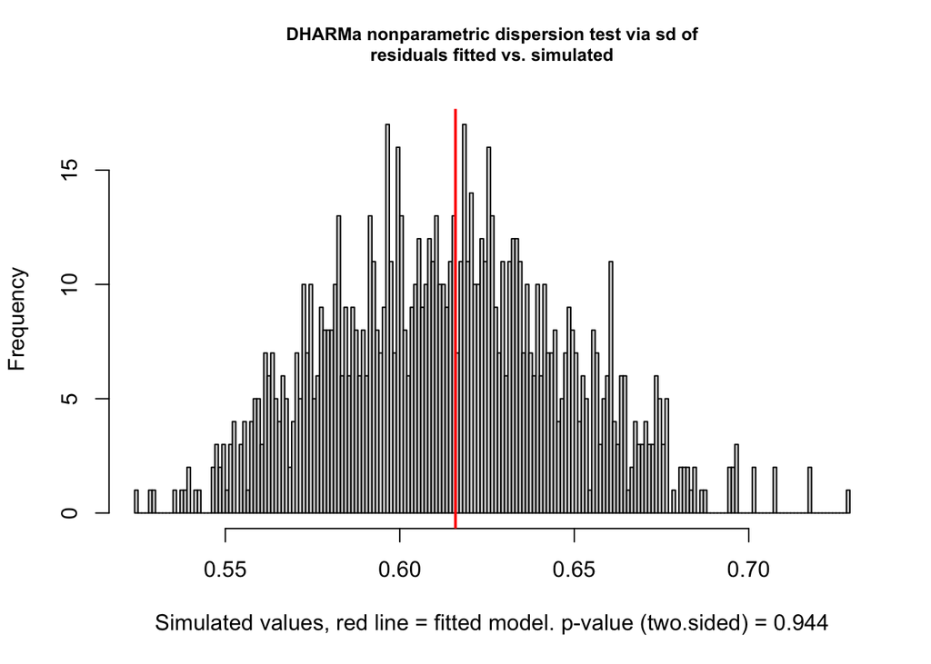

```
##
##  DHARMa nonparametric dispersion test via sd of residuals fitted vs.
##  simulated
##
## data:  simulationOutput
## dispersion = 1.0036, p-value = 0.944
## alternative hypothesis: two.sided
```

```r
# --- PLOT MODEL RESIDUALS --- #

# Simulate residuals from the fitted model

simulationOutput <- simulateResiduals(fittedModel = model,
                                      n = 1000)

# Test for overdispersion in the model to check if variance exceeds mean

testDispersion(simulationOutput)
```

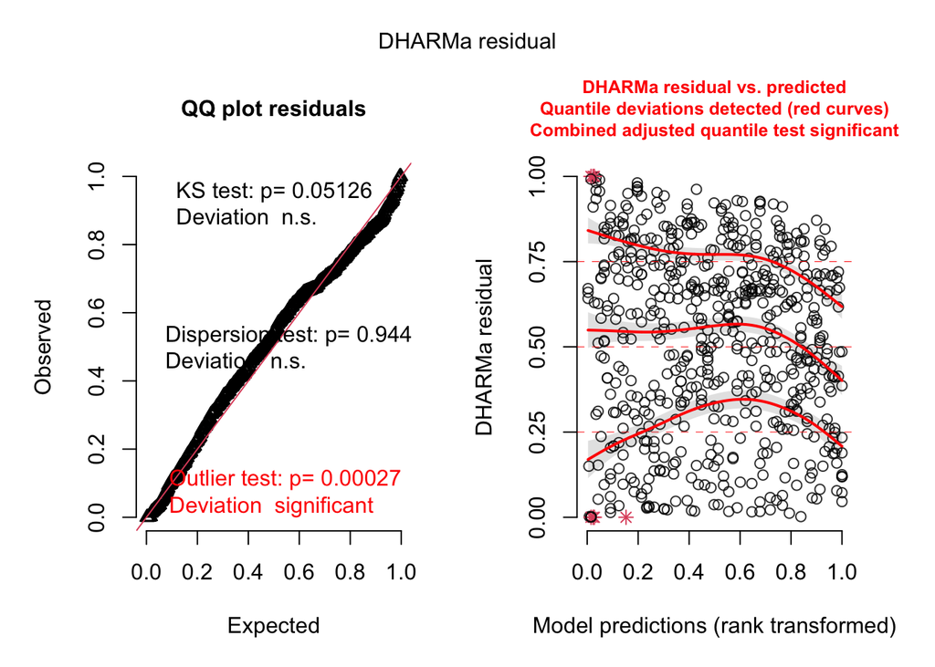

```r
# Plot Q-Q and Residuals vs Fitted plots

plot(simulationOutput)
```

### Median Size

```r
response_variable_selected = "median_body_area_µm2"
```

**Plot original data**

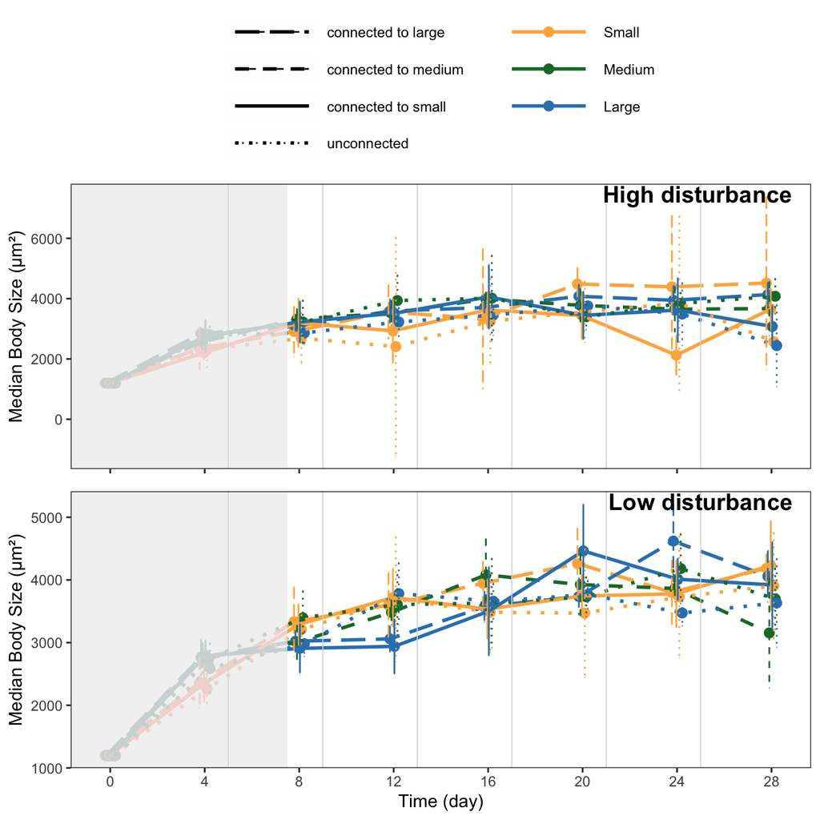

```r
# --- ORIGINAL DATA - PLOT MEAN ± 95% CI --- #

p1 = plot.all.patches.points(data = ds_ecosystems %>%
                               filter(disturbance == "high"),
                             response_variable_selected) +
  annotate("text",
           x = Inf,
           y = Inf,
           label = "High disturbance",
           hjust = 1.1,
           vjust = 1.1,
           size = 5,
           fontface = "bold") + # Adjust position and style
  theme(axis.title.x = element_blank(),  # Remove x-axis title
        axis.text.x = element_blank())  # Remove x-axis text
p2 = plot.all.patches.points(data = ds_ecosystems %>%
                               filter(disturbance == "low"),
                             response_variable_selected) +
  theme(legend.position = "none") +
  annotate("text",
           x = Inf,
           y = Inf,
           label = "Low disturbance",
           hjust = 1.1,
           vjust = 1.1,
           size = 5,
           fontface = "bold") # Adjust position and style

# Arrange the plots vertically

ggarrange(p1,
          p2,
          ncol = 1,
          nrow = 2,
          heights = c(1, 0.7))
```

**Prepare data for analysis**

```r
# --- PREPARE DATA FOR ANALYSIS --- #

# Add baselines

baselines = ds_ecosystems %>%
  filter(time_point == time_point_of_baselines) %>%
  select(ecosystem_ID,
         all_of(response_variable_selected)) %>%
  rename(baseline = all_of(response_variable_selected))

data_for_analysis = ds_ecosystems %>%
  left_join(baselines)

# Filter data and change level names

data_for_analysis = data_for_analysis %>%
  filter(time_point %in% time_points_model,
         #!is.na(water_addition_ml),
         !is.na(!!sym(response_variable_selected)),
         !is.infinite(!!sym(response_variable_selected))) %>%
  mutate(ecosystem_type = case_when(ecosystem_type == "Small unconnected" ~ "S",
                                    ecosystem_type == "Medium unconnected" ~ "M",
                                    ecosystem_type == "Large unconnected" ~ "L",
                                    ecosystem_type == "Small connected to small" ~ "S_S",
                                    ecosystem_type == "Small connected to large" ~ "S_L",
                                    ecosystem_type == "Medium connected to medium" ~ "M_M",
                                    ecosystem_type == "Large connected to large" ~ "L_L",
                                    ecosystem_type == "Large connected to small" ~ "L_S",
                                    TRUE ~ ecosystem_type)) %>%
  ungroup()
```

**Plot data for analysis means**

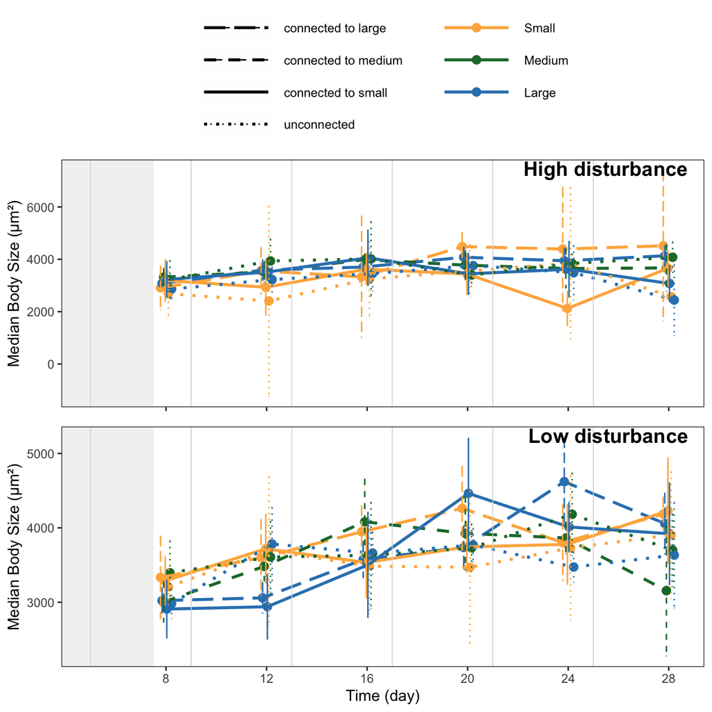

```r
# --- DATA FOR ANALYSIS - PLOT MEAN ± 95% CI --- #

p1 = plot.all.patches.points(data = data_for_analysis %>%
                               filter(disturbance == "high"),
                             response_variable_selected) +
  annotate("text",
           x = Inf,
           y = Inf,
           label = "High disturbance",
           hjust = 1.1,
           vjust = 1.1,
           size = 5,
           fontface = "bold") + # Adjust position and style
  theme(axis.title.x = element_blank(),  # Remove x-axis title
        axis.text.x = element_blank())  # Remove x-axis text
p2 = plot.all.patches.points(data = data_for_analysis %>%
                               filter(disturbance == "low"),
                             response_variable_selected) +
  theme(legend.position = "none") +
  annotate("text",
           x = Inf,
           y = Inf,
           label = "Low disturbance",
           hjust = 1.1,
           vjust = 1.1,
           size = 5,
           fontface = "bold") # Adjust position and style

# Arrange the plots vertically

ggarrange(p1,
          p2,
          ncol = 1,
          nrow = 2,
          heights = c(1, 0.7))
```

**Compute model results**

```r
# --- MODEL - CONSTRUCT --- #

# Define formula

formula = paste("get(response_variable_selected) ~",
                "ecosystem_type * disturbance * day +",
                "(day | ecosystem_ID) +",
                "(day | baseline)") %>%
  print()
```

```
## [1] "get(response_variable_selected) ~ ecosystem_type * disturbance * day + (day | ecosystem_ID) + (day | baseline)"
```

```r
# Construct model

model = try.different.optimizers.ecos(data_for_analysis,
                                      formula)
```

```
## [1] "Model successfully fitted with optimizer: bobyqa "
```

```r
# --- MODEL - SUMMARY --- #

print(summary(model), digits = 1)
```

```
## Linear mixed model fit by maximum likelihood . t-tests use Satterthwaite's
##   method [lmerModLmerTest]
## Formula: formula
##    Data: data
## Control: lmerControl(optimizer = opt$optimizer)
##
##       AIC       BIC    logLik -2*log(L)  df.resid
##   10359.9   10534.0   -5141.0   10281.9       602
##
## Scaled residuals:
##    Min     1Q Median     3Q    Max
##   -4.3   -0.5    0.0    0.5    3.8
##
## Random effects:
##  Groups       Name        Variance Std.Dev. Corr
##  ecosystem_ID (Intercept) 1e+02     11
##               day         1e+00      1      -1.00
##  baseline     (Intercept) 5e+04    220
##               day         5e+02     23      -1.00
##  Residual                 5e+05    702
## Number of obs: 641, groups:  ecosystem_ID, 109; baseline, 109
##
## Fixed effects:
##                                      Estimate Std. Error     df t value
## (Intercept)                             3e+03      4e+02  3e+02     8.9
## ecosystem_typeL_L                      -4e+02      5e+02  3e+02    -1.0
## ecosystem_typeL_S                       3e+02      5e+02  3e+02     0.5
## ecosystem_typeM                        -2e+01      5e+02  3e+02     0.0
## ecosystem_typeM_M                       7e+01      5e+02  3e+02     0.1
## ecosystem_typeS                        -1e+03      6e+02  3e+02    -2.1
## ecosystem_typeS_L                      -1e+03      5e+02  3e+02    -1.8
## ecosystem_typeS_S                      -1e+01      5e+02  3e+02     0.0
## disturbancelow                         -1e+02      5e+02  3e+02    -0.2
## day                                    -7e+00      2e+01  2e+02    -0.3
## ecosystem_typeL_L:disturbancelow       -4e+02      6e+02  3e+02    -0.6
## ecosystem_typeL_S:disturbancelow       -1e+03      7e+02  3e+02    -1.5
## ecosystem_typeM:disturbancelow          6e+01      7e+02  3e+02     0.1
## ecosystem_typeM_M:disturbancelow        6e+01      6e+02  3e+02     0.1
## ecosystem_typeS:disturbancelow          1e+03      8e+02  3e+02     1.5
## ecosystem_typeS_L:disturbancelow        9e+02      7e+02  3e+02     1.2
```

[output cut: 36 more lines]

```
## ecosystem_typeM:day                     0.303
## ecosystem_typeM_M:day                   0.423
## ecosystem_typeS:day                     0.059 .
## ecosystem_typeS_L:day                   0.003 **
## ecosystem_typeS_S:day                   0.895
## disturbancelow:day                      0.417
## ecosystem_typeL_L:disturbancelow:day    0.978
## ecosystem_typeL_S:disturbancelow:day    0.257
## ecosystem_typeM:disturbancelow:day      0.562
## ecosystem_typeM_M:disturbancelow:day    0.485
## ecosystem_typeS:disturbancelow:day      0.192
## ecosystem_typeS_L:disturbancelow:day    0.099 .
## ecosystem_typeS_S:disturbancelow:day    0.551
## ---
## Signif. codes:  0 '***' 0.001 '**' 0.01 '*' 0.05 '.' 0.1 ' ' 1
```

```
## optimizer (bobyqa) convergence code: 0 (OK)
## boundary (singular) fit: see help('isSingular')
```

```r
# --- MODEL - ANOVA --- #

car::Anova(model, type = "III")
```

```
## Analysis of Deviance Table (Type III Wald chisquare tests)
##
## Response: get(response_variable_selected)
##                                  Chisq Df Pr(>Chisq)
## (Intercept)                    79.3952  1  < 2.2e-16 ***
## ecosystem_type                 13.9138  7   0.052735 .
## disturbance                     0.0358  1   0.849880
## day                             0.1156  1   0.733851
## ecosystem_type:disturbance     12.4009  7   0.088122 .
## ecosystem_type:day             20.7688  7   0.004128 **
## disturbance:day                 0.6627  1   0.415609
## ecosystem_type:disturbance:day 13.0088  7   0.071895 .
## ---
## Signif. codes:  0 '***' 0.001 '**' 0.01 '*' 0.05 '.' 0.1 ' ' 1
```

```r
# --- ESTIMATE MARGINAL MEANS --- #

emmeans_output = emmeans(model,
                         specs = ~ ecosystem_type * disturbance * day,
                         adjust = "sidak",
                         bias.adj = TRUE,
                         lmer.df = "satterthwaite")

emmeans_output
```

```
##  ecosystem_type disturbance  day emmean  SE  df lower.CL upper.CL
##  L              high        17.8   3207 155 126     2741     3672
##  L_L            high        17.8   3747 109 126     3418     4076
##  L_S            high        17.8   3492 155 126     3027     3958
##  M              high        17.8   3745 155 126     3280     4211
##  M_M            high        17.8   3651 109 126     3322     3980
##  S              high        17.8   3165 198 202     2574     3756
##  S_L            high        17.8   3853 155 126     3387     4318
##  S_S            high        17.8   3130 115 146     2784     3476
##  L              low         17.8   3547 155 126     3082     4012
##  L_L            low         17.8   3667 109 126     3338     3996
##  L_S            low         17.8   3614 155 126     3148     4079
##  M              low         17.8   3704 155 126     3238     4169
##  M_M            low         17.8   3583 109 126     3254     3912
##  S              low         17.8   3569 157 131     3098     4041
##  S_L            low         17.8   3849 155 126     3383     4314
##  S_S            low         17.8   3710 109 126     3380     4039
##
## Degrees-of-freedom method: satterthwaite
## Results are given on the get (not the response) scale.
## Confidence level used: 0.95
## Conf-level adjustment: sidak method for 16 estimates
```

```r
# --- CODE EACH LEVEL OF DISTURBANCE AND ECOSYSTEM TYPE TO THEN PRODUCE CONTRASTS --- #

high_L = c(1, rep(0,15))
high_L_L = c(rep(0,1), 1, rep(0,14))
high_L_S = c(rep(0,2), 1, rep(0,13))
high_M = c(rep(0,3), 1, rep(0,12))
high_M_M = c(rep(0,4), 1, rep(0,11))
high_S = c(rep(0,5), 1, rep(0,10))
high_S_L = c(rep(0,6), 1, rep(0,9))
high_S_S = c(rep(0,7), 1, rep(0,8))
low_L = c(rep(0,8), 1, rep(0,7))
low_L_L = c(rep(0,9), 1, rep(0,6))
low_L_S = c(rep(0,10), 1, rep(0,5))
low_M = c(rep(0,11), 1, rep(0,4))
low_M_M = c(rep(0,12), 1, rep(0,3))
low_S = c(rep(0,13), 1, rep(0,2))
low_S_L = c(rep(0,14), 1, rep(0,1))
low_S_S = c(rep(0,15), 1)
```

```r
# --- PRODUCE ECOSYSTEM TYPE CONTRASTS --- #

# Set parameters

n_of_digits = 3

# Compute constrasts

contrasts = contrast(emmeans_output,
                     method = list("high S_L - S" = high_S_L - high_S,
                                   "high S_L - S_S" = high_S_L - high_S_S,
                                   "high S_S - S" = high_S_S - high_S,
                                   "high M_M - M" = high_M_M - high_M,
                                   "high L_S - L" = high_L_S - high_L,
                                   "high L_S - L_L" = high_L_S - high_L_L,
                                   "high L_L - L" = high_L_L - high_L,
                                   "low S_L - S" = low_S_L - low_S,
                                   "low S_L - S_S" = low_S_L - low_S_S,
                                   "low S_S - S" = low_S_S - low_S,
                                   "low M_M - M" = low_M_M - low_M,
                                   "low L_S - L" = low_L_S - low_L,
                                   "low L_S - L_L" = low_L_S - low_L_L,
                                   "low L_L - L" = low_L_L - low_L)) %>%
  as.data.frame() %>%
  mutate(p.value = round(p.value, digits = n_of_digits),
         estimate = round(estimate, digits = n_of_digits),
         SE = round(SE, digits = n_of_digits),
         df = round(df, digits = n_of_digits),
         t.ratio = round(t.ratio, digits = n_of_digits),
         e = "",
         e = ifelse(p.value > 0.1,
                           "",
                           e),
         e = ifelse(p.value < 0.05,
                           "*",
                           e),
         e = ifelse(p.value < 0.01,
                           "**",
                           e),
         e = ifelse(p.value < 0.001,
                           "***",
                           e)) %>%
  rename(" " = e)
```

**Show results**

```r
# --- SHOW ECOSYSTEM TYPE CONSTRASTS --- #

contrasts
```

```
##          contrast estimate      SE      df t.ratio p.value
## 1    high S_L - S  687.553 251.379 167.153   2.735   0.007  **
## 2  high S_L - S_S  723.003 193.147 132.515   3.743   0.000 ***
## 3    high S_S - S  -35.450 229.228 185.648  -0.155   0.877
## 4    high M_M - M  -93.928 189.642 125.540  -0.495   0.621
## 5    high L_S - L  285.749 218.979 125.540   1.305   0.194
## 6  high L_S - L_L -254.951 189.642 125.540  -1.344   0.181
## 7    high L_L - L  540.699 189.642 125.540   2.851   0.005  **
## 8     low S_L - S  279.243 220.579 128.429   1.266   0.208
## 9   low S_L - S_S  139.105 189.642 125.540   0.734   0.465
## 10    low S_S - S  140.139 191.487 129.393   0.732   0.466
## 11    low M_M - M -120.492 189.642 125.540  -0.635   0.526
## 12    low L_S - L   66.693 218.979 125.540   0.305   0.761
## 13  low L_S - L_L  -53.114 189.642 125.540  -0.280   0.780
## 14    low L_L - L  119.807 189.642 125.540   0.632   0.529
```

**Show model residuals residuals**

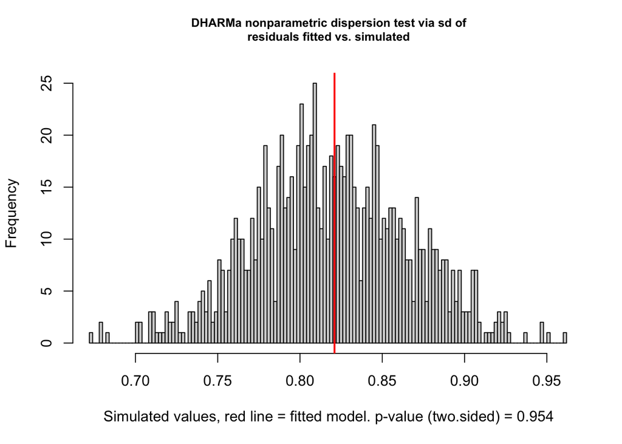

```
##
##  DHARMa nonparametric dispersion test via sd of residuals fitted vs.
##  simulated
##
## data:  simulationOutput
## dispersion = 1.0023, p-value = 0.954
## alternative hypothesis: two.sided
```

```r
# --- PLOT MODEL RESIDUALS --- #

# Simulate residuals from the fitted model

simulationOutput <- simulateResiduals(fittedModel = model,
                                      n = 1000)

# Test for overdispersion in the model to check if variance exceeds mean

testDispersion(simulationOutput)
```

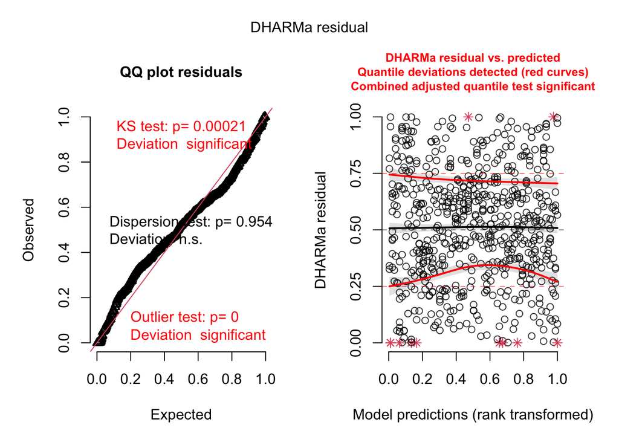

```r
# Plot Q-Q and Residuals vs Fitted plots

plot(simulationOutput)
```

### Photosynthetisers-heterotrophs ratio

```r
response_variable_selected = "photo_hetero_ratio"
```

**Plot original data**

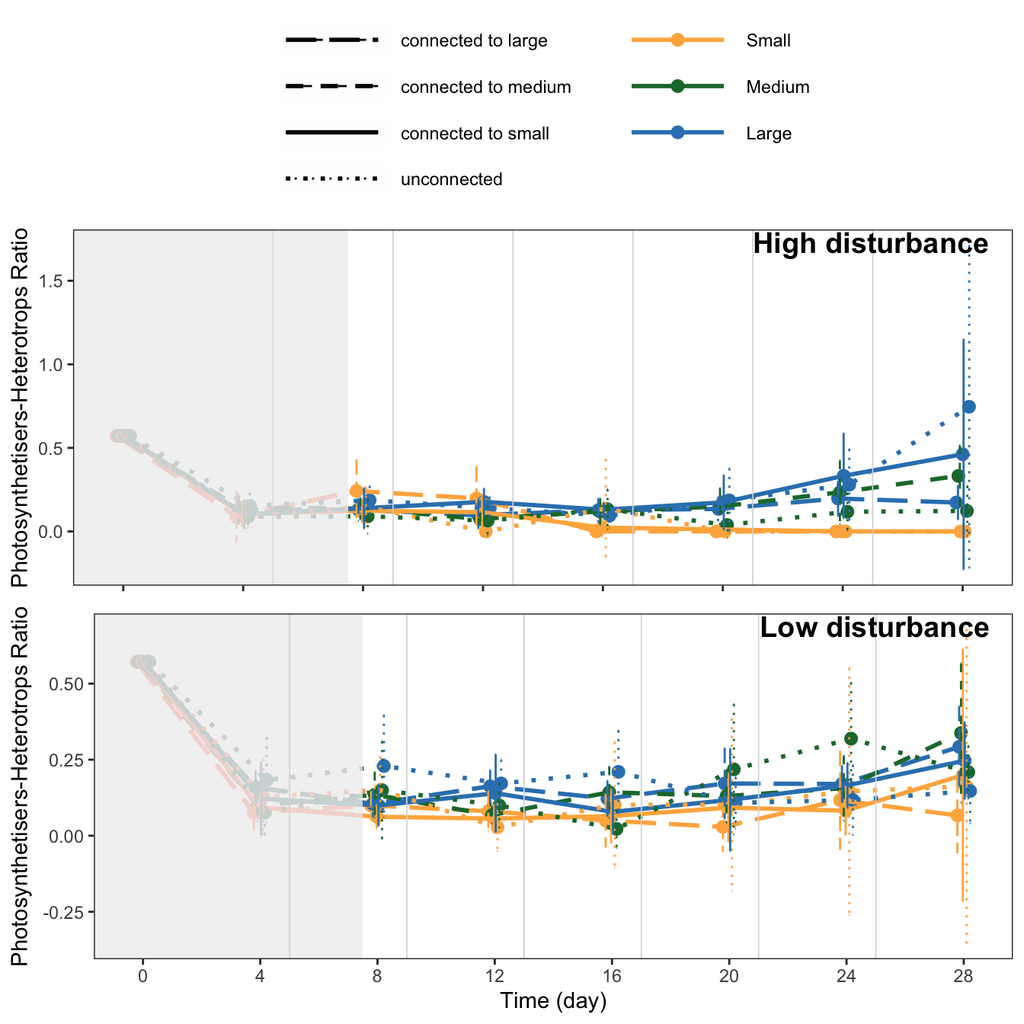

```r
# --- ORIGINAL DATA - PLOT MEAN ± 95% CI --- #

p1 = plot.all.patches.points(data = ds_ecosystems %>%
                               filter(disturbance == "high"),
                             response_variable_selected) +
  annotate("text",
           x = Inf,
           y = Inf,
           label = "High disturbance",
           hjust = 1.1,
           vjust = 1.1,
           size = 5,
           fontface = "bold") + # Adjust position and style
  theme(axis.title.x = element_blank(),  # Remove x-axis title
        axis.text.x = element_blank())  # Remove x-axis text
p2 = plot.all.patches.points(data = ds_ecosystems %>%
                               filter(disturbance == "low"),
                             response_variable_selected) +
  theme(legend.position = "none") +
  annotate("text",
           x = Inf,
           y = Inf,
           label = "Low disturbance",
           hjust = 1.1,
           vjust = 1.1,
           size = 5,
           fontface = "bold") # Adjust position and style

# Arrange the plots vertically

ggarrange(p1,
          p2,
          ncol = 1,
          nrow = 2,
          heights = c(1, 0.7))
```

**Prepare data for analysis**

```r
# --- PREPARE DATA FOR ANALYSIS --- #

# Add baselines

baselines = ds_ecosystems %>%
  filter(time_point == time_point_of_baselines) %>%
  select(ecosystem_ID,
         all_of(response_variable_selected)) %>%
  rename(baseline = all_of(response_variable_selected))

data_for_analysis = ds_ecosystems %>%
  left_join(baselines)

# Filter data and change level names

data_for_analysis = data_for_analysis %>%
  filter(time_point %in% time_points_model,
         #!is.na(water_addition_ml),
         !is.na(!!sym(response_variable_selected)),
         !is.infinite(!!sym(response_variable_selected))) %>%
  mutate(ecosystem_type = case_when(ecosystem_type == "Small unconnected" ~ "S",
                                    ecosystem_type == "Medium unconnected" ~ "M",
                                    ecosystem_type == "Large unconnected" ~ "L",
                                    ecosystem_type == "Small connected to small" ~ "S_S",
                                    ecosystem_type == "Small connected to large" ~ "S_L",
                                    ecosystem_type == "Medium connected to medium" ~ "M_M",
                                    ecosystem_type == "Large connected to large" ~ "L_L",
                                    ecosystem_type == "Large connected to small" ~ "L_S",
                                    TRUE ~ ecosystem_type)) %>%
  ungroup()
```

**Plot data for analysis means**

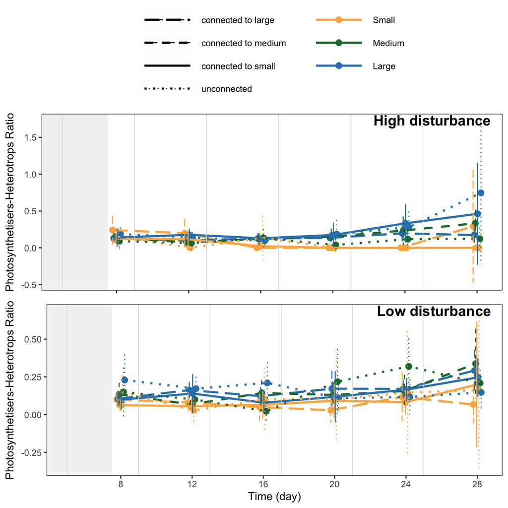

```r
# --- DATA FOR ANALYSIS - PLOT MEAN ± 95% CI --- #

p1 = plot.all.patches.points(data = data_for_analysis %>%
                               filter(disturbance == "high"),
                             response_variable_selected) +
  annotate("text",
           x = Inf,
           y = Inf,
           label = "High disturbance",
           hjust = 1.1,
           vjust = 1.1,
           size = 5,
           fontface = "bold") + # Adjust position and style
  theme(axis.title.x = element_blank(),  # Remove x-axis title
        axis.text.x = element_blank())  # Remove x-axis text
p2 = plot.all.patches.points(data = data_for_analysis %>%
                               filter(disturbance == "low"),
                             response_variable_selected) +
  theme(legend.position = "none") +
  annotate("text",
           x = Inf,
           y = Inf,
           label = "Low disturbance",
           hjust = 1.1,
           vjust = 1.1,
           size = 5,
           fontface = "bold") # Adjust position and style

# Arrange the plots vertically

ggarrange(p1,
          p2,
          ncol = 1,
          nrow = 2,
          heights = c(1, 0.7))
```

**Compute model results**

```r
# --- MODEL - CONSTRUCT --- #

# Define formula

formula = paste("get(response_variable_selected) ~",
                "ecosystem_type * disturbance * day +",
                "(day | ecosystem_ID) +",
                "(day | baseline)") %>%
  print()
```

```
## [1] "get(response_variable_selected) ~ ecosystem_type * disturbance * day + (day | ecosystem_ID) + (day | baseline)"
```

```r
# Construct model

model = try.different.optimizers.ecos(data_for_analysis,
                                      formula)
```

```
## [1] "Model successfully fitted with optimizer: bobyqa "
```

```r
# --- MODEL - SUMMARY --- #

print(summary(model), digits = 1)
```

```
## Linear mixed model fit by maximum likelihood . t-tests use Satterthwaite's
##   method [lmerModLmerTest]
## Formula: formula
##    Data: data
## Control: lmerControl(optimizer = opt$optimizer)
##
##       AIC       BIC    logLik -2*log(L)  df.resid
##    -447.3    -273.4     262.7    -525.3       600
##
## Scaled residuals:
##    Min     1Q Median     3Q    Max
##   -3.5   -0.5   -0.1    0.3    8.0
##
## Random effects:
##  Groups       Name        Variance Std.Dev. Corr
##  ecosystem_ID (Intercept) 9e-12    3e-06
##               day         5e-14    2e-07    -1.00
##  baseline     (Intercept) 1e-02    1e-01
##               day         9e-05    9e-03    -1.00
##  Residual                 2e-02    1e-01
## Number of obs: 639, groups:  ecosystem_ID, 109; baseline, 104
##
## Fixed effects:
##                                      Estimate Std. Error     df t value
## (Intercept)                            -2e-01      9e-02  2e+02    -1.7
## ecosystem_typeL_L                       2e-01      1e-01  2e+02     1.9
## ecosystem_typeL_S                       1e-01      1e-01  2e+02     0.9
## ecosystem_typeM                         2e-01      1e-01  2e+02     1.7
## ecosystem_typeM_M                       1e-01      1e-01  2e+02     1.2
## ecosystem_typeS                         3e-01      1e-01  2e+02     2.2
## ecosystem_typeS_L                       4e-01      1e-01  2e+02     2.9
## ecosystem_typeS_S                       3e-01      1e-01  2e+02     3.0
## disturbancelow                          4e-01      1e-01  2e+02     3.1
## day                                     2e-02      6e-03  1e+02     4.1
## ecosystem_typeL_L:disturbancelow       -4e-01      2e-01  2e+02    -2.6
## ecosystem_typeL_S:disturbancelow       -3e-01      2e-01  2e+02    -1.8
## ecosystem_typeM:disturbancelow         -4e-01      2e-01  2e+02    -2.4
## ecosystem_typeM_M:disturbancelow       -4e-01      2e-01  2e+02    -2.4
## ecosystem_typeS:disturbancelow         -5e-01      2e-01  2e+02    -2.7
## ecosystem_typeS_L:disturbancelow       -6e-01      2e-01  2e+02    -3.1
```

[output cut: 36 more lines]

```
## ecosystem_typeM:day                     0.008 **
## ecosystem_typeM_M:day                   0.066 .
## ecosystem_typeS:day                     0.001 **
## ecosystem_typeS_L:day                   1e-04 ***
## ecosystem_typeS_S:day                   2e-05 ***
## disturbancelow:day                      6e-04 ***
## ecosystem_typeL_L:disturbancelow:day    0.002 **
## ecosystem_typeL_S:disturbancelow:day    0.093 .
## ecosystem_typeM:disturbancelow:day      0.003 **
## ecosystem_typeM_M:disturbancelow:day    0.008 **
## ecosystem_typeS:disturbancelow:day      0.002 **
## ecosystem_typeS_L:disturbancelow:day    0.001 **
## ecosystem_typeS_S:disturbancelow:day    4e-05 ***
## ---
## Signif. codes:  0 '***' 0.001 '**' 0.01 '*' 0.05 '.' 0.1 ' ' 1
```

```
## optimizer (bobyqa) convergence code: 0 (OK)
## boundary (singular) fit: see help('isSingular')
```

```r
# --- MODEL - ANOVA --- #

car::Anova(model, type = "III")
```

```
## Analysis of Deviance Table (Type III Wald chisquare tests)
##
## Response: get(response_variable_selected)
##                                  Chisq Df Pr(>Chisq)
## (Intercept)                     2.7671  1   0.096223 .
## ecosystem_type                 15.6135  7   0.028892 *
## disturbance                     9.6490  1   0.001895 **
## day                            17.0660  1  3.610e-05 ***
## ecosystem_type:disturbance     16.4222  7   0.021527 *
## ecosystem_type:day             32.9063  7  2.756e-05 ***
## disturbance:day                12.3799  1   0.000434 ***
## ecosystem_type:disturbance:day 22.2663  7   0.002285 **
## ---
## Signif. codes:  0 '***' 0.001 '**' 0.01 '*' 0.05 '.' 0.1 ' ' 1
```

```r
# --- ESTIMATE MARGINAL MEANS --- #

emmeans_output = emmeans(model,
                         specs = ~ ecosystem_type * disturbance * day,
                         adjust = "sidak",
                         bias.adj = TRUE,
                         lmer.df = "satterthwaite")

emmeans_output
```

```
##  ecosystem_type disturbance  day emmean     SE  df lower.CL upper.CL
##  L              high        17.8 0.2681 0.0349 135  0.16348    0.373
##  L_L            high        17.8 0.1483 0.0238 182  0.07714    0.219
##  L_S            high        17.8 0.2331 0.0349 135  0.12846    0.338
##  M              high        17.8 0.0943 0.0349 135 -0.01038    0.199
##  M_M            high        17.8 0.1727 0.0247 135  0.09868    0.247
##  S              high        17.8 0.0432 0.0439 202 -0.08773    0.174
##  S_L            high        17.8 0.1013 0.0330 251  0.00313    0.199
##  S_S            high        17.8 0.0389 0.0255 196 -0.03734    0.115
##  L              low         17.8 0.1648 0.0349 135  0.06019    0.269
##  L_L            low         17.8 0.1655 0.0238 182  0.09432    0.237
##  L_S            low         17.8 0.1403 0.0349 135  0.03565    0.245
##  M              low         17.8 0.1682 0.0349 135  0.06355    0.273
##  M_M            low         17.8 0.1581 0.0238 182  0.08700    0.229
##  S              low         17.8 0.1202 0.0354 141  0.01408    0.226
##  S_L            low         17.8 0.0773 0.0327 236 -0.01993    0.175
##  S_S            low         17.8 0.0918 0.0247 135  0.01782    0.166
##
## Degrees-of-freedom method: satterthwaite
## Results are given on the get (not the response) scale.
## Confidence level used: 0.95
## Conf-level adjustment: sidak method for 16 estimates
```

```r
# --- CODE EACH LEVEL OF DISTURBANCE AND ECOSYSTEM TYPE TO THEN PRODUCE CONTRASTS --- #

high_L = c(1, rep(0,15))
high_L_L = c(rep(0,1), 1, rep(0,14))
high_L_S = c(rep(0,2), 1, rep(0,13))
high_M = c(rep(0,3), 1, rep(0,12))
high_M_M = c(rep(0,4), 1, rep(0,11))
high_S = c(rep(0,5), 1, rep(0,10))
high_S_L = c(rep(0,6), 1, rep(0,9))
high_S_S = c(rep(0,7), 1, rep(0,8))
low_L = c(rep(0,8), 1, rep(0,7))
low_L_L = c(rep(0,9), 1, rep(0,6))
low_L_S = c(rep(0,10), 1, rep(0,5))
low_M = c(rep(0,11), 1, rep(0,4))
low_M_M = c(rep(0,12), 1, rep(0,3))
low_S = c(rep(0,13), 1, rep(0,2))
low_S_L = c(rep(0,14), 1, rep(0,1))
low_S_S = c(rep(0,15), 1)
```

```r
# --- PRODUCE ECOSYSTEM TYPE CONTRASTS --- #

# Set parameters

n_of_digits = 3

# Compute constrasts

contrasts = contrast(emmeans_output,
         method = list("high L - S" = high_L - high_S,
                       "high M - S" = high_M - high_S,
                       "low L - S" = low_L - low_S,
                       "low M - S" = low_M - low_S)) %>%
  as.data.frame() %>%
  mutate(p.value = round(p.value, digits = n_of_digits),
         estimate = round(estimate, digits = n_of_digits),
         SE = round(SE, digits = n_of_digits),
         df = round(df, digits = n_of_digits),
         t.ratio = round(t.ratio, digits = n_of_digits),
         e = "",
         e = ifelse(p.value > 0.1,
                           "",
                           e),
         e = ifelse(p.value < 0.05,
                           "*",
                           e),
         e = ifelse(p.value < 0.01,
                           "**",
                           e),
         e = ifelse(p.value < 0.001,
                           "***",
                           e)) %>%
  rename(" " = e)
```

**Show results**

```r
# --- SHOW ECOSYSTEM TYPE CONSTRASTS --- #

contrasts
```

```
##     contrast estimate    SE      df t.ratio p.value
## 1 high L - S    0.225 0.056 172.002   4.013   0.000 ***
## 2 high M - S    0.051 0.056 172.002   0.911   0.364
## 3  low L - S    0.045 0.050 137.957   0.899   0.370
## 4  low M - S    0.048 0.050 137.957   0.967   0.335
```

**Show model residuals residuals**

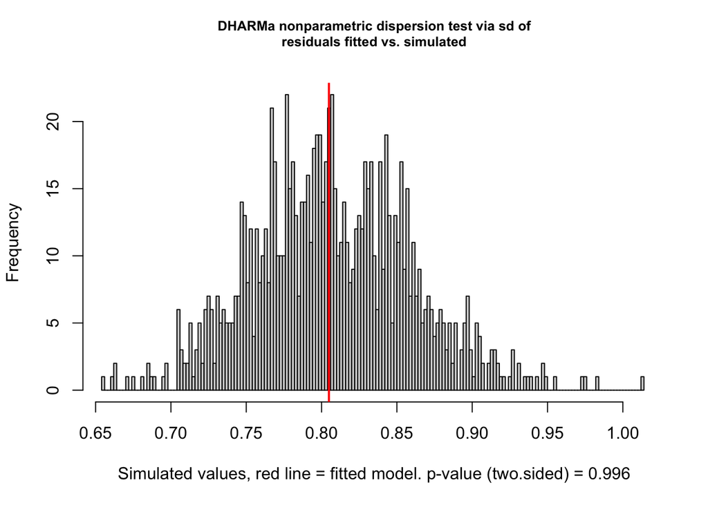

```
##
##  DHARMa nonparametric dispersion test via sd of residuals fitted vs.
##  simulated
##
## data:  simulationOutput
## dispersion = 0.99756, p-value = 0.996
## alternative hypothesis: two.sided
```

```r
# --- PLOT MODEL RESIDUALS --- #

# Simulate residuals from the fitted model

simulationOutput <- simulateResiduals(fittedModel = model,
                                      n = 1000)

# Test for overdispersion in the model to check if variance exceeds mean

testDispersion(simulationOutput)
```

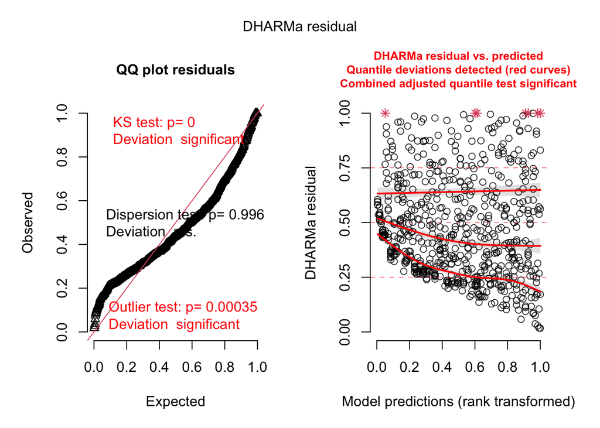

```r
# Plot Q-Q and Residuals vs Fitted plots

plot(simulationOutput)
```

### BEF relationship

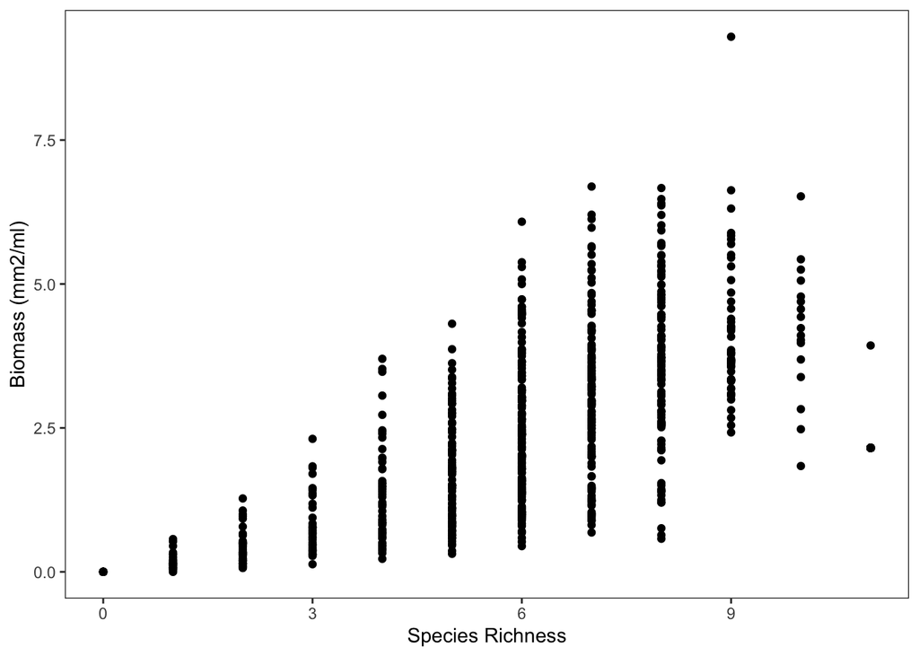

```r
# --- PLOT BIOMASS-SPECIES RICHNESS RELATIONSHIP --- #

ds_ecosystems %>%
    filter(is.na(species_richness) != TRUE) %>%
    ggplot(aes(x = species_richness,
               y = bioarea_mm2_per_ml)) +
    geom_point() +
    xlim(0, length(protist_species)) +
    labs(x = axis_names$axis_name[axis_names$variable == "species_richness"],
         y = axis_names$axis_name[axis_names$variable == "bioarea_mm2_per_ml"]) +
    theme_bw() +
    theme(panel.grid.major = element_blank(),
          panel.grid.minor = element_blank(),
          legend.position = legend_position,
          legend.key.width = unit(legend_width_cm, "cm"))
```

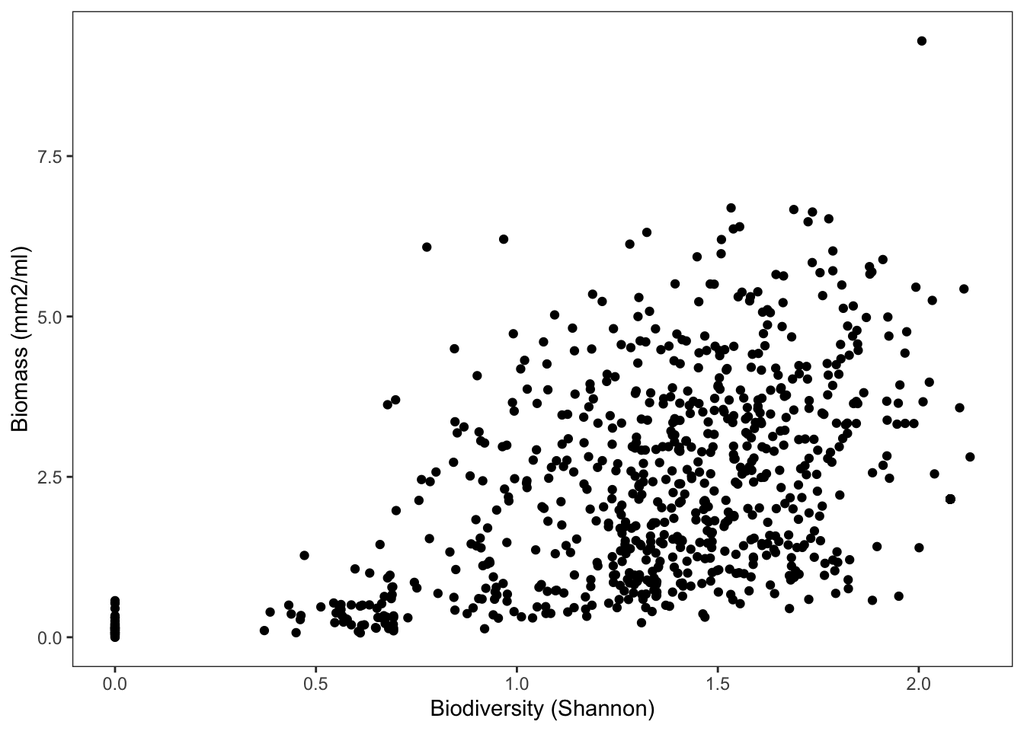

```r
# --- PLOT BIOMASS-SHANNON RELATIONSHIP --- #

ds_ecosystems %>%
  filter(is.na(shannon) != TRUE) %>%
  ggplot(aes(x = shannon,
             y = bioarea_mm2_per_ml)) +
  geom_point() +
  labs(x = axis_names$axis_name[axis_names$variable == "shannon"],
       y = axis_names$axis_name[axis_names$variable == "bioarea_mm2_per_ml"]) +
  theme_bw() +
    theme(panel.grid.major = element_blank(),
          panel.grid.minor = element_blank(),
          legend.position = legend_position,
          legend.key.width = unit(legend_width_cm, "cm"))
```

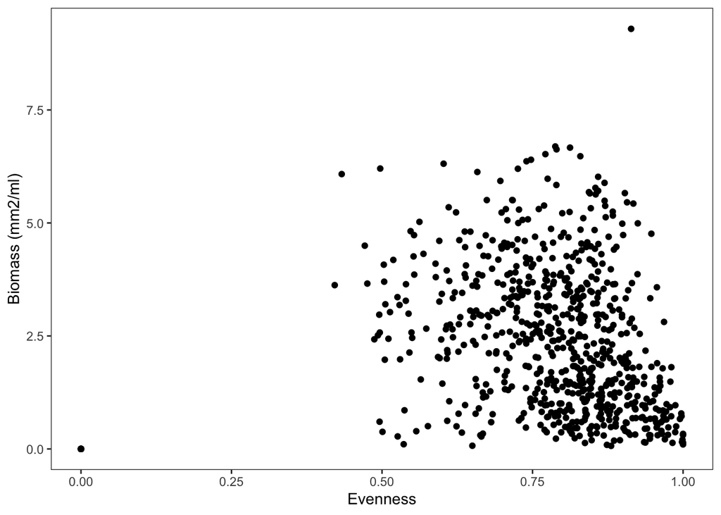

```r
# --- PLOT BIOMASS-EVENESS RELATIONSHIP --- #

ds_ecosystems %>%
  filter(is.na(evenness_pielou) != TRUE) %>%
  ggplot(aes(x = evenness_pielou,
             y = bioarea_mm2_per_ml)) +
  geom_point() +
  labs(x = axis_names$axis_name[axis_names$variable == "evenness_pielou"],
       y = axis_names$axis_name[axis_names$variable == "bioarea_mm2_per_ml"]) +
  theme_bw() +
    theme(panel.grid.major = element_blank(),
          panel.grid.minor = element_blank(),
          legend.position = legend_position,
          legend.key.width = unit(legend_width_cm, "cm"))
```

## Figures

### High disturbance

```r
disturbance_selected = "high"
```

```r
# --- PREPARE DATA FOR PLOTTING --- #

# Define what you want to plot

metaecosystem_type_selected = c("Medium-Medium",
                                "Small-Large")

# Filter dataset

data_for_plotting = ds_metaecosystems %>%
  filter(metaecosystem_type %in% metaecosystem_type_selected,
         disturbance == disturbance_selected)
```

```r
# Write function to plot a response variable. Afterwards you can use this function to plot alpha, beta, gamma diversity, and biomass.

plot.single.plot = function(response_variable_selected){

  data_for_plotting %>%
    filter(metaecosystem_type %in% metaecosystem_type_selected,
           !is.na(!!sym(response_variable_selected))) %>%
    summarySE(measurevar = response_variable_selected,
              groupvars = c("day", "ecosystem_size_symmetry", "connection")) %>%
    ggplot(aes(x = day,
               y = get(response_variable_selected),
               group = interaction(day, ecosystem_size_symmetry, connection),
               color = ecosystem_size_symmetry,
               linetype = connection)) +
    geom_point(stat = "summary",
               fun = "mean",
               position = position_dodge(dodging),
               size = treatment_points_size) +
    geom_line(stat = "summary",
              fun = "mean",
              aes(group = interaction(ecosystem_size_symmetry, connection)),
              position = position_dodge(dodging),
              linewidth = treatment_lines_linewidth) +
    geom_errorbar(aes(ymax = get(response_variable_selected) + ci,
                      ymin = get(response_variable_selected) - ci),
                  width = width_errorbar,
                  position = position_dodge(dodging)) +
    labs(x = axis_names$axis_name[axis_names$variable == "day"],
         y = axis_names$axis_name[axis_names$variable == response_variable_selected],
         color = "") +
    scale_color_manual(values = treatment_colours_paper) +
    scale_linetype_manual(values = treatment_linetype_paper) +
    geom_vline(xintercept = resource_flow_days,
               linetype = resource_flow_line_type,
               color = resource_flow_line_colour,
               linewidth = resource_flow_line_width) +
    theme_bw() +
    theme(panel.grid.major = element_blank(),
          panel.grid.minor = element_blank(),
          legend.position = legend_position,
          legend.key.width = unit(legend_width_cm, "cm")) +
    guides(color = guide_legend(title = NULL,
                                nrow = 2),
           linetype = guide_legend(title = NULL,
                                   nrow = 2)) +
    theme(plot.margin = unit(c(ggarrange_margin_left,
                               ggarrange_margin_right,
                               ggarrange_margin_bottom,
                               ggarrange_margin_left),
                             "cm")) +
    geom_rect(xmin = grey_background_xmin,
              xmax = grey_background_xmax,
              ymin = grey_background_ymin,
              ymax = grey_background_ymax,
              fill = grey_background_fill,
              alpha = grey_background_alpha,
              color = grey_background_color)
}
```

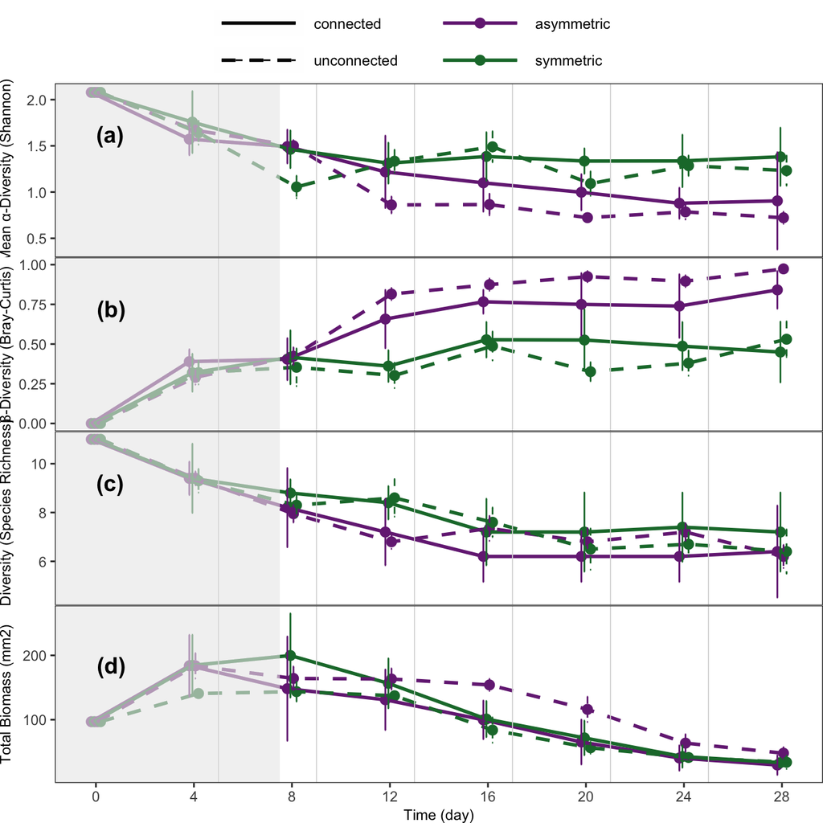

```r
# Combine plots of alpha, beta, gamma biodiversity and biomass.

p_combined = ggarrange(plot.single.plot("mean_shannon") +
                         rremove("xlab") +
                         theme(axis.text.x = element_blank(),
                               axis.ticks.x = element_blank()) +
                         font("legend.text", size = paper_labels_size) +
                         font("ylab", size = paper_labels_size),
                       plot.single.plot("bray_curtis") +
                         rremove("xlab") +
                         theme(axis.text.x = element_blank(),
                               axis.ticks.x = element_blank()) +
                         font("legend.text",
                              size = paper_labels_size) +
                         font("ylab",
                              size = paper_labels_size),
                       plot.single.plot("metaecosystem_richness") +
                         rremove("xlab") +
                         theme(axis.text.x = element_blank(),
                               axis.ticks.x = element_blank()) +
                         font("legend.text",
                              size = paper_labels_size) +
                         font("ylab",
                              size = paper_labels_size),
                       plot.single.plot("total_metaecosystem_bioarea_mm2") +
                         font("legend.text",
                              size = paper_labels_size) +
                         font("xlab",
                              size = paper_labels_size) +
                         font("ylab",
                              size = paper_labels_size) +
                         scale_x_continuous(breaks = unique(data_for_plotting$day)),
                       heights = c(0.8, 0.8, 0.8, 1),
                       nrow = 4,
                       common.legend = TRUE,
                       align = "v",
                       labels = c("(a)", "(b)", "(c)", "(d)"),
                       label.x = 0.1,
                       label.y = 0.8) %>%
  print()
```

```r
# --- PREPARE DATA FOR PLOTTING --- #

# Define parameters

ecosystem_type_selected = c("Small connected to large",
                            "Small connected to small",
                            "Small unconnected",
                            "Large connected to small",
                            "Large connected to large",
                            "Large unconnected")

# Filter data

data_for_plotting = ds_ecosystems %>%
  filter(ecosystem_type %in% ecosystem_type_selected,
         disturbance == disturbance_selected)
```

```r
# --- CONSTRUCT FUNCTION TO PLOT BIOMASS/SHANNON OF SMALL AND LARGE ECOSYSTEMS --- #

plot.single.plot = function(response_variable_selected){

  data_for_plotting %>%
    filter(!is.na(!!sym(response_variable_selected))) %>%
    summarySE(measurevar = response_variable_selected,
              groupvars = c("day", "time_point", "ecosystem_type", "ecosystem_size", "connection")) %>%
    ggplot(aes(x = day,
               y = get(response_variable_selected),
               group = interaction(day, ecosystem_type),
               color = ecosystem_type,
               linetype = ecosystem_type)) +
    geom_point(stat = "summary",
               fun = "mean",
               position = position_dodge(dodging),
               size = treatment_points_size) +
    geom_line(stat = "summary",
              fun = "mean",
              aes(group = ecosystem_type),
              position = position_dodge(dodging),
              linewidth = treatment_lines_linewidth) +
    geom_errorbar(aes(ymax = get(response_variable_selected) + ci,
                      ymin = get(response_variable_selected) - ci),
                  width = width_errorbar,
                  position = position_dodge(dodging)) +
    labs(x = axis_names$axis_name[axis_names$variable == "day"],
         y = axis_names$axis_name[axis_names$variable == response_variable_selected],
         color = "") +
    scale_color_manual(values = c("#993404",
                                  "#993404",
                                  "#993404",
                                  "#3182bd",
                                  "#3182bd",
                                  "#3182bd"),
                       label = expression(S[L],
                                          S[S],
                                          S,
                                          L[S],
                                          L[L],
                                          L)) +
    scale_linetype_manual(values = c("solid",
                                     "dashed",
                                     "dotted",
                                     "solid",
                                     "dashed",
                                     "dotted"),
                          label = expression(S[L],
                                             S[S],
                                             S,
                                             L[S],
                                             L[L],
                                             L)) +
    geom_vline(xintercept = resource_flow_days,
               linetype = resource_flow_line_type,
               color = resource_flow_line_colour,
               linewidth = resource_flow_line_width) +
    geom_hline(yintercept = 0,
               color = zero_line_colour,
               linetype = zero_line_line_type,
               linewidth = zero_line_line_width) +
    theme_bw() +
    theme(panel.grid.major = element_blank(),
          panel.grid.minor = element_blank(),
          legend.position = legend_position,
          legend.key.width = unit(legend_width_cm, "cm")) +
    guides(color = guide_legend(title = NULL,
                                nrow = 3),
           linetype = guide_legend(title = NULL,
                                   nrow = 3)) +
    geom_rect(xmin = grey_background_xmin,
              xmax = grey_background_xmax,
              ymin = grey_background_ymin,
              ymax = grey_background_ymax,
              fill = grey_background_fill,
              alpha = grey_background_alpha,
              color = grey_background_color)
}
```

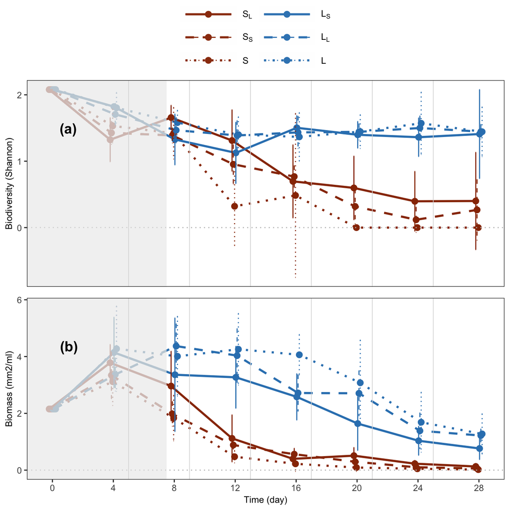

```r
# --- COMBINE PLOTS OF SHANNON AND BIOMASS --- #

p_combined = ggarrange(plot.single.plot("shannon") +
                         rremove("xlab") +
                         theme(axis.text.x = element_blank(),
                               axis.ticks.x = element_blank()) +
                         font("legend.text",
                              size = paper_labels_size) +
                         font("ylab",
                              size = paper_labels_size),
                       plot.single.plot("bioarea_mm2_per_ml") +
                         font("legend.text",
                              size = paper_labels_size) +
                         font("xlab",
                              size = paper_labels_size) +
                         font("ylab",
                              size = paper_labels_size) +
                         scale_x_continuous(breaks = unique(data_for_plotting$day)),
                       heights = c(0.8, 0.8, 1),
                       nrow = 2,
                       align = "v",
                       labels = c("(a)", "(b)"),
                       label.x = 0.1,
                       label.y = 0.8,
                       common.legend = TRUE) %>%
  print()
```

```r
# --- PREPARE DATA FOR PLOTTING --- #

# Define parameters

ecosystem_type_selected = c("Medium connected to medium",
                            "Medium unconnected")

# Filter data

data_for_plotting = ds_ecosystems %>%
  filter(ecosystem_type %in% ecosystem_type_selected,
         disturbance == disturbance_selected,
         !is.na(!!sym(response_variable_selected)))
```

```r
# --- CONSTRUCT FUNCTION TO PLOT BIOMASS/SHANNON OF MEDIUM ECOSYSTEMS --- #

plot.single.plot = function(response_variable_selected){

  data_for_plotting %>%
    summarySE(measurevar = response_variable_selected,
              groupvars = c("day", "time_point", "ecosystem_type", "ecosystem_size", "connection")) %>%
    ggplot(aes(x = day,
               y = get(response_variable_selected),
               group = interaction(day, ecosystem_type),
               color = ecosystem_type,
               linetype = ecosystem_type)) +
    geom_point(stat = "summary",
               fun = "mean",
               position = position_dodge(dodging),
               size = treatment_points_size) +
    geom_line(stat = "summary",
              fun = "mean",
              aes(group = ecosystem_type),
              position = position_dodge(dodging),
              linewidth = treatment_lines_linewidth) +
    geom_errorbar(aes(ymax = get(response_variable_selected) + ci,
                      ymin = get(response_variable_selected) - ci),
                  width = width_errorbar,
                  position = position_dodge(dodging)) +
    labs(x = axis_names$axis_name[axis_names$variable == "day"],
         y = axis_names$axis_name[axis_names$variable == response_variable_selected],
         color = "") +
    scale_color_manual(values = c("#d95f0e",
                                  "#d95f0e"),
                       label = expression(M[M],
                                          M)) +
    scale_linetype_manual(values = c("dashed",
                                     "dotted"),
                          label = expression(M[M],
                                             M)) +
    geom_vline(xintercept = resource_flow_days,
               linetype = resource_flow_line_type,
               color = resource_flow_line_colour,
               linewidth = resource_flow_line_width) +
    geom_hline(yintercept = 0,
               color = zero_line_colour,
               linetype = zero_line_line_type,
               linewidth = zero_line_line_width) +
    theme_bw() +
    theme(panel.grid.major = element_blank(),
          panel.grid.minor = element_blank(),
          legend.position = legend_position,
          legend.key.width = unit(legend_width_cm, "cm")) +
    guides(color = guide_legend(title = NULL,
                                nrow = 3),
           linetype = guide_legend(title = NULL,
                                   nrow = 3)) +
    geom_rect(xmin = grey_background_xmin,
              xmax = grey_background_xmax,
              ymin = grey_background_ymin,
              ymax = grey_background_ymax,
              fill = grey_background_fill,
              alpha = grey_background_alpha,
              color = grey_background_color)
}
```

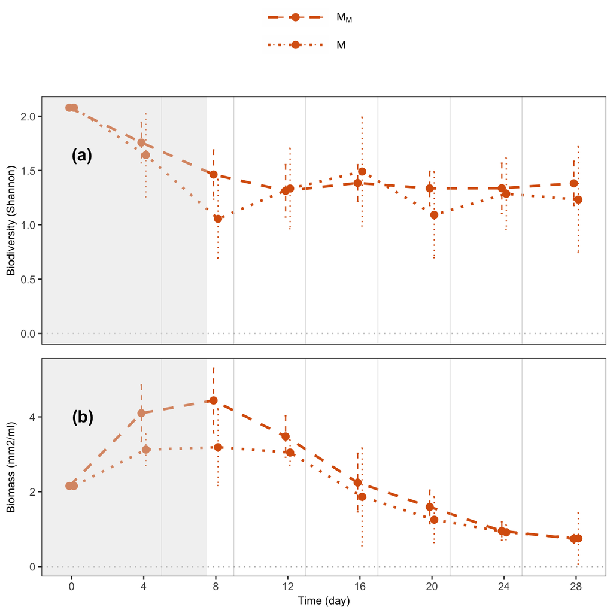

```r
# --- COMBINE PLOTS OF SHANNON AND BIOMASS --- #

p_combined = ggarrange(plot.single.plot("shannon") +
                         rremove("xlab") +
                         theme(axis.text.x = element_blank(),
                               axis.ticks.x = element_blank()) +
                         font("legend.text",
                              size = paper_labels_size) +
                         font("ylab",
                              size = paper_labels_size),
                       plot.single.plot("bioarea_mm2_per_ml") +
                         font("legend.text",
                              size = paper_labels_size) +
                         font("xlab",
                              size = paper_labels_size) +
                         font("ylab",
                              size = paper_labels_size) +
                         scale_x_continuous(breaks = unique(data_for_plotting$day)),
                       heights = c(0.8, 0.8, 1),
                       nrow = 2,
                       align = "v",
                       labels = c("(a)", "(b)"),
                       label.x = 0.1,
                       label.y = 0.8,
                       common.legend = TRUE) %>%
  print()
```

```r
# --- DEFINE RESPONSE VARIABLE YOU WANT TO PLOT --- #

response_variable = "photo_hetero_ratio"
```

```r
# --- PREPARE DATA FOR PLOTTING --- #

# Define parameters

ecosystem_type_selected = c("S",
                            "M",
                            "L")

# Manipulate data

data_for_plotting = ds_ecosystems %>%
  mutate(ecosystem_type = case_when(ecosystem_type == "Small unconnected" ~ "S",
                                    ecosystem_type == "Medium unconnected" ~ "M",
                                    ecosystem_type == "Large unconnected" ~ "L")) %>%
  filter(ecosystem_type %in% ecosystem_type_selected,
         disturbance == disturbance_selected,
         !is.na(!!sym(response_variable)))
```

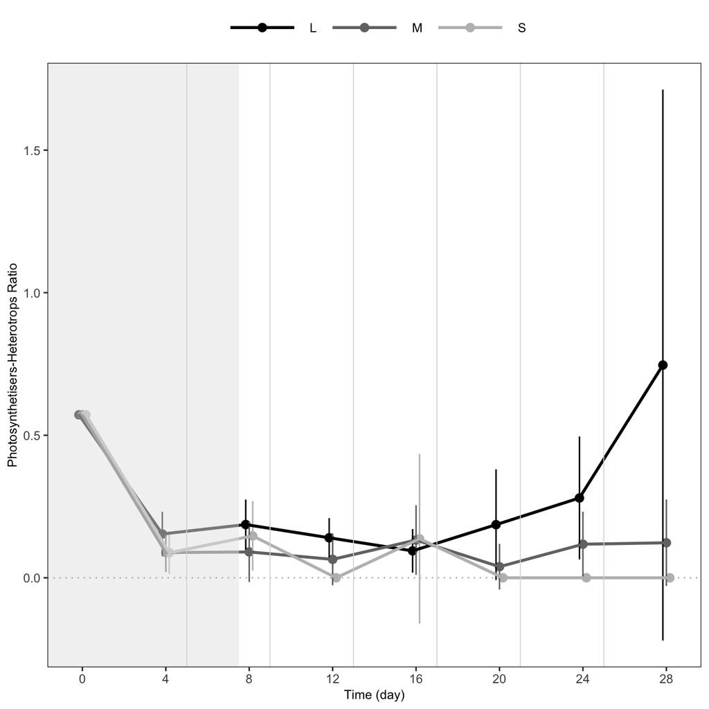

```r
# --- CONSTRUCT PLOT --- #

p = data_for_plotting %>%

  # Manipulate

  summarySE(measurevar = response_variable,
            groupvars = c("day", "ecosystem_type", "ecosystem_size", "connection")) %>%

  # Create plot

  ggplot(aes(x = day,
             y = get(response_variable),
             group = interaction(day, ecosystem_type),
             color = ecosystem_type)) +

  # Points

  geom_point(stat = "summary",
             fun = "mean",
             position = position_dodge(dodging),
             size = treatment_points_size) +
  geom_errorbar(aes(ymax = get(response_variable) + ci,
                    ymin = get(response_variable) - ci),
                width = width_errorbar,
                position = position_dodge(dodging)) +

  # Lines

  geom_line(stat = "summary",
            fun = "mean",
            aes(group = ecosystem_type),
            position = position_dodge(dodging),
            linewidth = treatment_lines_linewidth) +

  # Axes and legend

  labs(x = axis_names$axis_name[axis_names$variable == "day"],
       y = axis_names$axis_name[axis_names$variable == response_variable],
       color = "") +
  scale_x_continuous(breaks = unique(data_for_plotting$day)) +
  guides(color = guide_legend(title = NULL,
                              nrow = 1),
         linetype = guide_legend(title = NULL,
                                 nrow = 1)) +
  scale_color_manual(values = c("#000000",
                                "#737373",
                                "#bdbdbd")) +

  # Extra graphic elements

  theme_bw() +
  theme(panel.grid.major = element_blank(),
        panel.grid.minor = element_blank(),
        legend.position = legend_position,
        legend.key.width = unit(legend_width_cm, "cm"),
        axis.title.x = element_text(size = paper_labels_size),
        axis.title.y = element_text(size = paper_labels_size),
        legend.text = element_text(size = paper_labels_size)) +
  geom_rect(xmin = grey_background_xmin,
            xmax = grey_background_xmax,
            ymin = grey_background_ymin,
            ymax = grey_background_ymax,
            fill = grey_background_fill,
            alpha = grey_background_alpha,
            color = grey_background_color) +
  geom_hline(yintercept = 0,
             color = zero_line_colour,
             linetype = zero_line_line_type,
             linewidth = zero_line_line_width) +

  geom_vline(xintercept = resource_flow_days,
             linetype = resource_flow_line_type,
             color = resource_flow_line_colour,
             linewidth = resource_flow_line_width)
p
```

**Figures to present**

```r
# --- DEFINE PLOTTING PARAMETERS --- #

legend_row_n_input = 2
size_y_axis = 22
x_min = -0.2
x_max = 30
y_min = -0.8
y_max = 3
```

```r
# --- PREPARE DATA FOR PLOTTING --- #

# Define parameters

ecosystem_type_all = c("Small connected to large",
                       "Small unconnected",
                       "Small connected to small",
                       "Large connected to small",
                       "Large unconnected",
                       "Large connected to large")

response_variable_selected = "shannon"

# Filter data

data_for_plotting = ds_ecosystems %>%
  filter(ecosystem_type %in% ecosystem_type_all,
         disturbance == disturbance_selected)
```

```r
# --- CONSTRUCT PLOTS --- #

# Define parameters

plots = NULL

# Construct plots

plots[[1]] = plot.ecosystems.empty.presentations(y_min_alpha,
                                                 y_max_alpha,
                                                 "shannon")

for (i in 1:length(ecosystem_type_all)+1) {

  plots[[i+1]] = plot.ecosystems.points.presentations(data = data_for_plotting,
                                                      ecosystem_type_selected = ecosystem_type_all[1:i],
                                                      response_variable_selected) +
    theme(plot.margin = unit(c(ggarrange_margin_left,
                               ggarrange_margin_right,
                               ggarrange_margin_bottom,
                               ggarrange_margin_left),
                             "cm"),
          legend.position = "none") +
    scale_y_continuous(labels = scales::number_format(accuracy = 0.01)) +
    xlim(x_min, x_max) +
    ylim(y_min, y_max)

  }
# --- COMBINE PLOTS --- #

# Define parameters

p_combined = NULL
p_combined[[1]] = plots[[1]]

# Combine plots

for(i in 1:length(ecosystem_type_all)+1){

  p_combined[[i]] = ggarrange(plots[[i]] +
                                theme(axis.text = element_text(size = presentation_axes_size)) +
                                font("legend.text", size = size_legend) +
                                font("xlab", size = size_y_axis) +
                                font("ylab", size = size_y_axis),
                              nrow = 1,
                              align = "v",
                              label.x = 0.1,
                              label.y = 0.8)

  }
# --- SAVE COMBINED PLOTS --- #

for(i in 1:length(ecosystem_type_all)+1){

  png(file = here("..",
                  "3_results",
                  "figures",
                  paste0(disturbance_selected, "_disturbance"),
                  "presentations",
                  paste0("ecosystems_connected_diversity_", i, ".png")),
      width = presentation_figure_width,
      height = presentation_figure_height,
      units = presentation_figure_units,
      res = presentation_figure_res)

  print(p_combined[[i]])

  dev.off()

  }
```

### Low disturbance

```r
disturbance_selected = "low"
```

```r
# --- PREPARE DATA FOR PLOTTING --- #

# Define what you want to plot

metaecosystem_type_selected = c("Medium-Medium",
                                "Small-Large")

# Filter dataset

data_for_plotting = ds_metaecosystems %>%
  filter(metaecosystem_type %in% metaecosystem_type_selected,
         disturbance == disturbance_selected)
```

```r
# Write function to plot a response variable. Afterwards you can use this function to plot alpha, beta, gamma diversity, and biomass.

plot.single.plot = function(response_variable_selected){

  data_for_plotting %>%
    filter(metaecosystem_type %in% metaecosystem_type_selected,
           !is.na(!!sym(response_variable_selected))) %>%
    summarySE(measurevar = response_variable_selected,
              groupvars = c("day", "ecosystem_size_symmetry", "connection")) %>%
    ggplot(aes(x = day,
               y = get(response_variable_selected),
               group = interaction(day, ecosystem_size_symmetry, connection),
               color = ecosystem_size_symmetry,
               linetype = connection)) +
    geom_point(stat = "summary",
               fun = "mean",
               position = position_dodge(dodging),
               size = treatment_points_size) +
    geom_line(stat = "summary",
              fun = "mean",
              aes(group = interaction(ecosystem_size_symmetry, connection)),
              position = position_dodge(dodging),
              linewidth = treatment_lines_linewidth) +
    geom_errorbar(aes(ymax = get(response_variable_selected) + ci,
                      ymin = get(response_variable_selected) - ci),
                  width = width_errorbar,
                  position = position_dodge(dodging)) +
    labs(x = axis_names$axis_name[axis_names$variable == "day"],
         y = axis_names$axis_name[axis_names$variable == response_variable_selected],
         color = "") +
    scale_color_manual(values = treatment_colours_paper) +
    scale_linetype_manual(values = treatment_linetype_paper) +
    geom_vline(xintercept = resource_flow_days,
               linetype = resource_flow_line_type,
               color = resource_flow_line_colour,
               linewidth = resource_flow_line_width) +
    theme_bw() +
    theme(panel.grid.major = element_blank(),
          panel.grid.minor = element_blank(),
          legend.position = legend_position,
          legend.key.width = unit(legend_width_cm, "cm")) +
    guides(color = guide_legend(title = NULL,
                                nrow = 2),
           linetype = guide_legend(title = NULL,
                                   nrow = 2)) +
    theme(plot.margin = unit(c(ggarrange_margin_left,
                               ggarrange_margin_right,
                               ggarrange_margin_bottom,
                               ggarrange_margin_left),
                             "cm")) +
    geom_rect(xmin = grey_background_xmin,
              xmax = grey_background_xmax,
              ymin = grey_background_ymin,
              ymax = grey_background_ymax,
              fill = grey_background_fill,
              alpha = grey_background_alpha,
              color = grey_background_color)
}
```

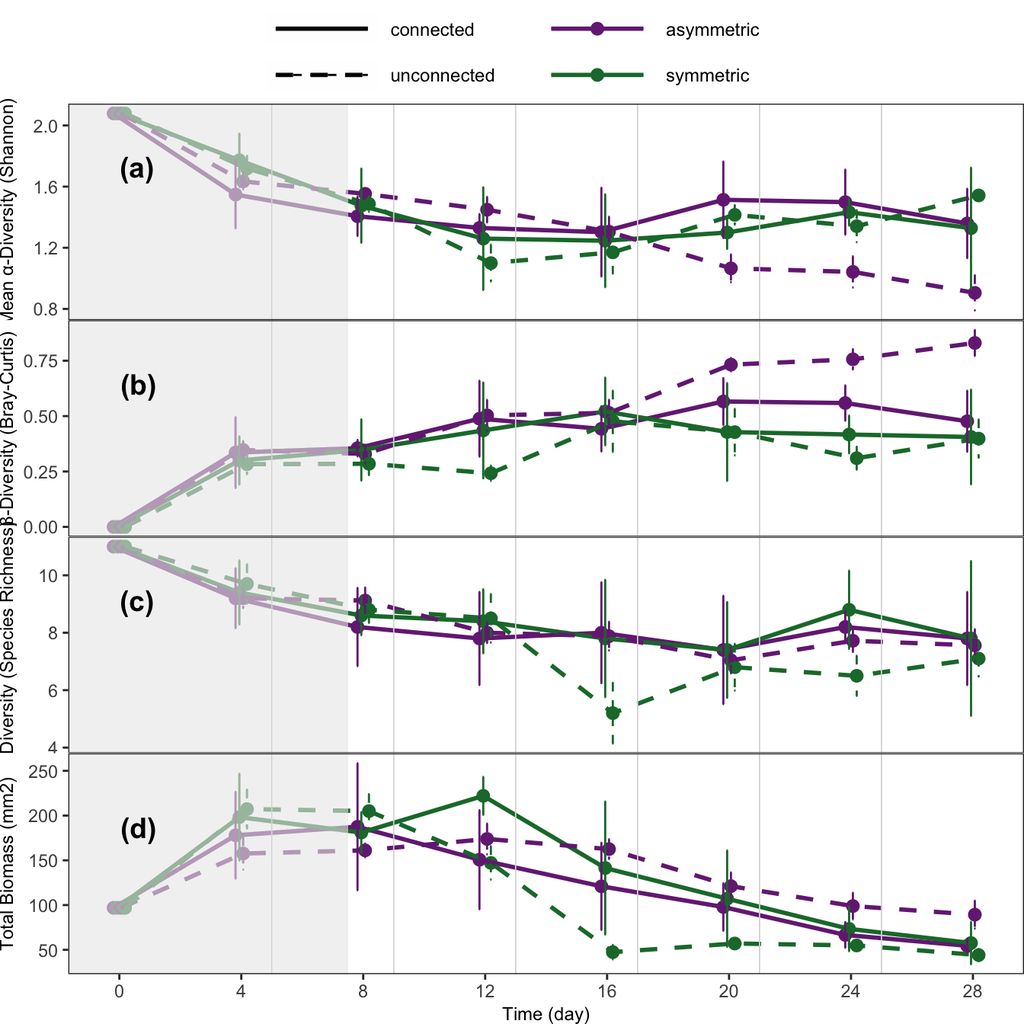

```r
# Combine plots of alpha, beta, gamma biodiversity and biomass.

p_combined = ggarrange(plot.single.plot("mean_shannon") +
                         rremove("xlab") +
                         theme(axis.text.x = element_blank(),
                               axis.ticks.x = element_blank()) +
                         font("legend.text", size = paper_labels_size) +
                         font("ylab", size = paper_labels_size),
                       plot.single.plot("bray_curtis") +
                         rremove("xlab") +
                         theme(axis.text.x = element_blank(),
                               axis.ticks.x = element_blank()) +
                         font("legend.text",
                              size = paper_labels_size) +
                         font("ylab",
                              size = paper_labels_size),
                       plot.single.plot("metaecosystem_richness") +
                         rremove("xlab") +
                         theme(axis.text.x = element_blank(),
                               axis.ticks.x = element_blank()) +
                         font("legend.text",
                              size = paper_labels_size) +
                         font("ylab",
                              size = paper_labels_size),
                       plot.single.plot("total_metaecosystem_bioarea_mm2") +
                         font("legend.text",
                              size = paper_labels_size) +
                         font("xlab",
                              size = paper_labels_size) +
                         font("ylab",
                              size = paper_labels_size) +
                         scale_x_continuous(breaks = unique(data_for_plotting$day)),
                       heights = c(0.8, 0.8, 0.8, 1),
                       nrow = 4,
                       common.legend = TRUE,
                       align = "v",
                       labels = c("(a)", "(b)", "(c)", "(d)"),
                       label.x = 0.1,
                       label.y = 0.8) %>%
  print()
```

```r
# --- PREPARE DATA FOR PLOTTING --- #

# Define parameters

ecosystem_type_selected = c("Small connected to large",
                            "Small connected to small",
                            "Small unconnected",
                            "Large connected to small",
                            "Large connected to large",
                            "Large unconnected")

# Filter data

data_for_plotting = ds_ecosystems %>%
  filter(ecosystem_type %in% ecosystem_type_selected,
         disturbance == disturbance_selected)
```

```r
# --- CONSTRUCT FUNCTION TO PLOT BIOMASS/SHANNON OF SMALL AND LARGE ECOSYSTEMS --- #

plot.single.plot = function(response_variable_selected){

  data_for_plotting %>%
    filter(!is.na(!!sym(response_variable_selected))) %>%
    summarySE(measurevar = response_variable_selected,
              groupvars = c("day", "time_point", "ecosystem_type", "ecosystem_size", "connection")) %>%
    ggplot(aes(x = day,
               y = get(response_variable_selected),
               group = interaction(day, ecosystem_type),
               color = ecosystem_type,
               linetype = ecosystem_type)) +
    geom_point(stat = "summary",
               fun = "mean",
               position = position_dodge(dodging),
               size = treatment_points_size) +
    geom_line(stat = "summary",
              fun = "mean",
              aes(group = ecosystem_type),
              position = position_dodge(dodging),
              linewidth = treatment_lines_linewidth) +
    geom_errorbar(aes(ymax = get(response_variable_selected) + ci,
                      ymin = get(response_variable_selected) - ci),
                  width = width_errorbar,
                  position = position_dodge(dodging)) +
    labs(x = axis_names$axis_name[axis_names$variable == "day"],
         y = axis_names$axis_name[axis_names$variable == response_variable_selected],
         color = "") +
    scale_color_manual(values = c("#993404",
                                  "#993404",
                                  "#993404",
                                  "#3182bd",
                                  "#3182bd",
                                  "#3182bd"),
                       label = expression(S[L],
                                          S[S],
                                          S,
                                          L[S],
                                          L[L],
                                          L)) +
    scale_linetype_manual(values = c("solid",
                                     "dashed",
                                     "dotted",
                                     "solid",
                                     "dashed",
                                     "dotted"),
                          label = expression(S[L],
                                             S[S],
                                             S,
                                             L[S],
                                             L[L],
                                             L)) +
    geom_vline(xintercept = resource_flow_days,
               linetype = resource_flow_line_type,
               color = resource_flow_line_colour,
               linewidth = resource_flow_line_width) +
    geom_hline(yintercept = 0,
               color = zero_line_colour,
               linetype = zero_line_line_type,
               linewidth = zero_line_line_width) +
    theme_bw() +
    theme(panel.grid.major = element_blank(),
          panel.grid.minor = element_blank(),
          legend.position = legend_position,
          legend.key.width = unit(legend_width_cm, "cm")) +
    guides(color = guide_legend(title = NULL,
                                nrow = 3),
           linetype = guide_legend(title = NULL,
                                   nrow = 3)) +
    geom_rect(xmin = grey_background_xmin,
              xmax = grey_background_xmax,
              ymin = grey_background_ymin,
              ymax = grey_background_ymax,
              fill = grey_background_fill,
              alpha = grey_background_alpha,
              color = grey_background_color)
}
```

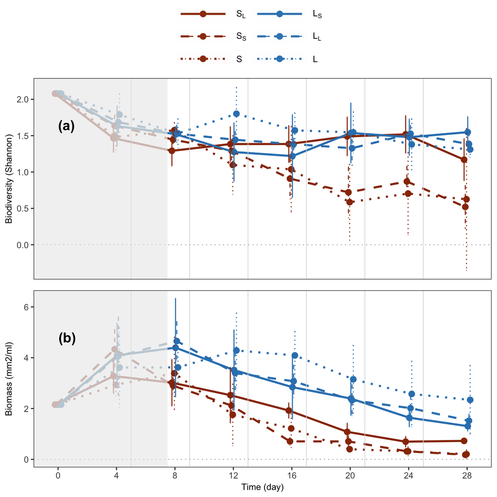

```r
# --- COMBINE PLOTS OF SHANNON AND BIOMASS --- #

p_combined = ggarrange(plot.single.plot("shannon") +
                         rremove("xlab") +
                         theme(axis.text.x = element_blank(),
                               axis.ticks.x = element_blank()) +
                         font("legend.text",
                              size = paper_labels_size) +
                         font("ylab",
                              size = paper_labels_size),
                       plot.single.plot("bioarea_mm2_per_ml") +
                         font("legend.text",
                              size = paper_labels_size) +
                         font("xlab",
                              size = paper_labels_size) +
                         font("ylab",
                              size = paper_labels_size) +
                         scale_x_continuous(breaks = unique(data_for_plotting$day)),
                       heights = c(0.8, 0.8, 1),
                       nrow = 2,
                       align = "v",
                       labels = c("(a)", "(b)"),
                       label.x = 0.1,
                       label.y = 0.8,
                       common.legend = TRUE) %>%
  print()
```

```r
# --- PREPARE DATA FOR PLOTTING --- #

# Define parameters

ecosystem_type_selected = c("Medium connected to medium",
                            "Medium unconnected")

# Filter data

data_for_plotting = ds_ecosystems %>%
  filter(ecosystem_type %in% ecosystem_type_selected,
         disturbance == disturbance_selected,
         !is.na(!!sym(response_variable_selected)))
```

```r
# --- CONSTRUCT FUNCTION TO PLOT BIOMASS/SHANNON OF MEDIUM ECOSYSTEMS --- #

plot.single.plot = function(response_variable_selected){

  data_for_plotting %>%
    summarySE(measurevar = response_variable_selected,
              groupvars = c("day", "time_point", "ecosystem_type", "ecosystem_size", "connection")) %>%
    ggplot(aes(x = day,
               y = get(response_variable_selected),
               group = interaction(day, ecosystem_type),
               color = ecosystem_type,
               linetype = ecosystem_type)) +
    geom_point(stat = "summary",
               fun = "mean",
               position = position_dodge(dodging),
               size = treatment_points_size) +
    geom_line(stat = "summary",
              fun = "mean",
              aes(group = ecosystem_type),
              position = position_dodge(dodging),
              linewidth = treatment_lines_linewidth) +
    geom_errorbar(aes(ymax = get(response_variable_selected) + ci,
                      ymin = get(response_variable_selected) - ci),
                  width = width_errorbar,
                  position = position_dodge(dodging)) +
    labs(x = axis_names$axis_name[axis_names$variable == "day"],
         y = axis_names$axis_name[axis_names$variable == response_variable_selected],
         color = "") +
    scale_color_manual(values = c("#d95f0e",
                                  "#d95f0e"),
                       label = expression(M[M],
                                          M)) +
    scale_linetype_manual(values = c("dashed",
                                     "dotted"),
                          label = expression(M[M],
                                             M)) +
    geom_vline(xintercept = resource_flow_days,
               linetype = resource_flow_line_type,
               color = resource_flow_line_colour,
               linewidth = resource_flow_line_width) +
    geom_hline(yintercept = 0,
               color = zero_line_colour,
               linetype = zero_line_line_type,
               linewidth = zero_line_line_width) +
    theme_bw() +
    theme(panel.grid.major = element_blank(),
          panel.grid.minor = element_blank(),
          legend.position = legend_position,
          legend.key.width = unit(legend_width_cm, "cm")) +
    guides(color = guide_legend(title = NULL,
                                nrow = 3),
           linetype = guide_legend(title = NULL,
                                   nrow = 3)) +
    geom_rect(xmin = grey_background_xmin,
              xmax = grey_background_xmax,
              ymin = grey_background_ymin,
              ymax = grey_background_ymax,
              fill = grey_background_fill,
              alpha = grey_background_alpha,
              color = grey_background_color)
}
```

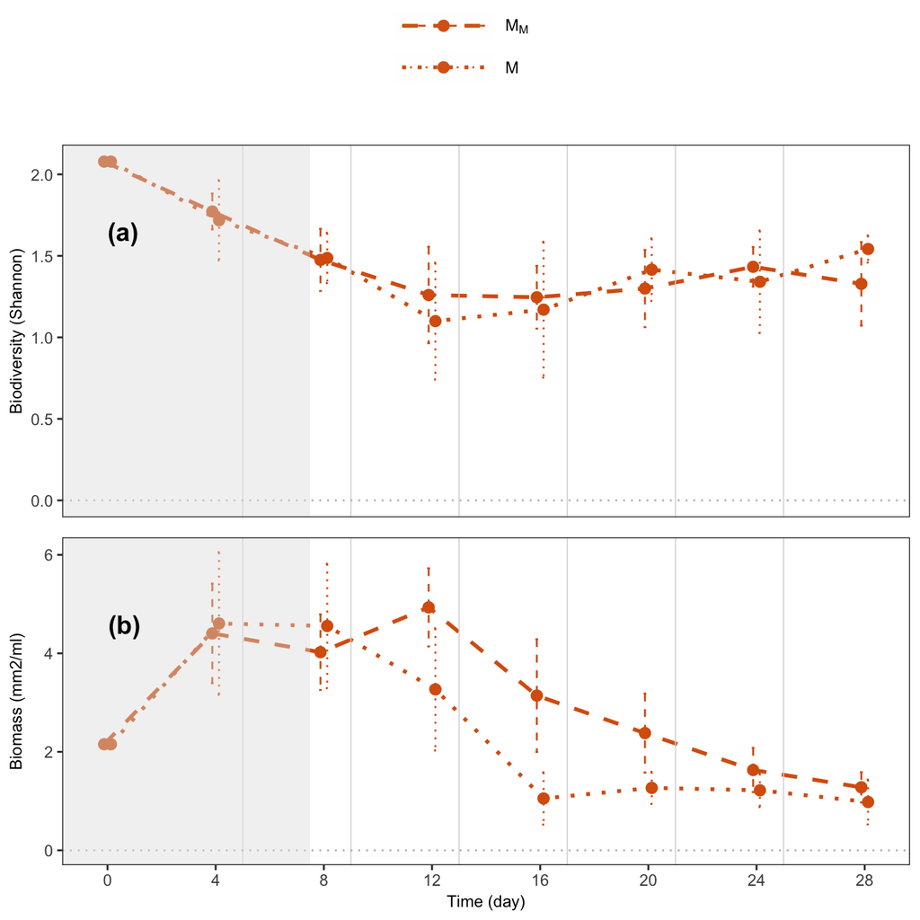

```r
# --- COMBINE PLOTS OF SHANNON AND BIOMASS --- #

p_combined = ggarrange(plot.single.plot("shannon") +
                         rremove("xlab") +
                         theme(axis.text.x = element_blank(),
                               axis.ticks.x = element_blank()) +
                         font("legend.text",
                              size = paper_labels_size) +
                         font("ylab",
                              size = paper_labels_size),
                       plot.single.plot("bioarea_mm2_per_ml") +
                         font("legend.text",
                              size = paper_labels_size) +
                         font("xlab",
                              size = paper_labels_size) +
                         font("ylab",
                              size = paper_labels_size) +
                         scale_x_continuous(breaks = unique(data_for_plotting$day)),
                       heights = c(0.8, 0.8, 1),
                       nrow = 2,
                       align = "v",
                       labels = c("(a)", "(b)"),
                       label.x = 0.1,
                       label.y = 0.8,
                       common.legend = TRUE) %>%
  print()
```

```r
# --- DEFINE RESPONSE VARIABLE YOU WANT TO PLOT --- #

response_variable = "photo_hetero_ratio"
```

```r
# --- PREPARE DATA FOR PLOTTING --- #

# Define parameters

ecosystem_type_selected = c("S",
                            "M",
                            "L")

# Manipulate data

data_for_plotting = ds_ecosystems %>%
  mutate(ecosystem_type = case_when(ecosystem_type == "Small unconnected" ~ "S",
                                    ecosystem_type == "Medium unconnected" ~ "M",
                                    ecosystem_type == "Large unconnected" ~ "L")) %>%
  filter(ecosystem_type %in% ecosystem_type_selected,
         disturbance == disturbance_selected,
         !is.na(!!sym(response_variable)))
```

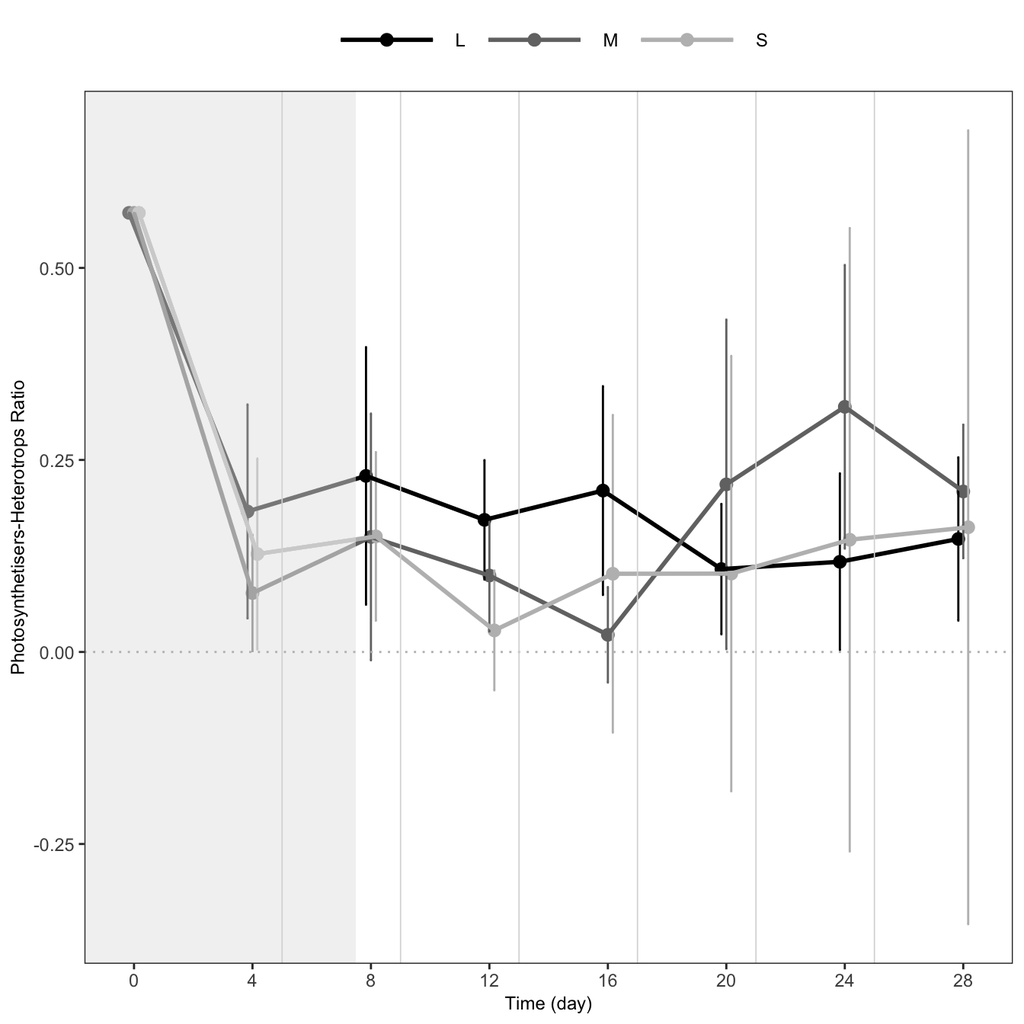

```r
# --- CONSTRUCT PLOT --- #

p = data_for_plotting %>%

  # Manipulate

  summarySE(measurevar = response_variable,
            groupvars = c("day", "ecosystem_type", "ecosystem_size", "connection")) %>%

  # Create plot

  ggplot(aes(x = day,
             y = get(response_variable),
             group = interaction(day, ecosystem_type),
             color = ecosystem_type)) +

  # Points

  geom_point(stat = "summary",
             fun = "mean",
             position = position_dodge(dodging),
             size = treatment_points_size) +
  geom_errorbar(aes(ymax = get(response_variable) + ci,
                    ymin = get(response_variable) - ci),
                width = width_errorbar,
                position = position_dodge(dodging)) +

  # Lines

  geom_line(stat = "summary",
            fun = "mean",
            aes(group = ecosystem_type),
            position = position_dodge(dodging),
            linewidth = treatment_lines_linewidth) +

  # Axes and legend

  labs(x = axis_names$axis_name[axis_names$variable == "day"],
       y = axis_names$axis_name[axis_names$variable == response_variable],
       color = "") +
  scale_x_continuous(breaks = unique(data_for_plotting$day)) +
  guides(color = guide_legend(title = NULL,
                              nrow = 1),
         linetype = guide_legend(title = NULL,
                                 nrow = 1)) +
  scale_color_manual(values = c("#000000",
                                "#737373",
                                "#bdbdbd")) +

  # Extra graphic elements

  theme_bw() +
  theme(panel.grid.major = element_blank(),
        panel.grid.minor = element_blank(),
        legend.position = legend_position,
        legend.key.width = unit(legend_width_cm, "cm"),
        axis.title.x = element_text(size = paper_labels_size),
        axis.title.y = element_text(size = paper_labels_size),
        legend.text = element_text(size = paper_labels_size)) +
  geom_rect(xmin = grey_background_xmin,
            xmax = grey_background_xmax,
            ymin = grey_background_ymin,
            ymax = grey_background_ymax,
            fill = grey_background_fill,
            alpha = grey_background_alpha,
            color = grey_background_color) +
  geom_hline(yintercept = 0,
             color = zero_line_colour,
             linetype = zero_line_line_type,
             linewidth = zero_line_line_width) +

  geom_vline(xintercept = resource_flow_days,
             linetype = resource_flow_line_type,
             color = resource_flow_line_colour,
             linewidth = resource_flow_line_width)

p
```

**Figures to present**

```r
# --- DEFINE PLOTTING PARAMETERS --- #

legend_row_n_input = 2
size_y_axis = 22
x_min = -0.2
x_max = 30
y_min = -0.8
y_max = 3
```

```r
# --- PREPARE DATA FOR PLOTTING --- #

# Define parameters

ecosystem_type_all = c("Small connected to large",
                       "Small unconnected",
                       "Small connected to small",
                       "Large connected to small",
                       "Large unconnected",
                       "Large connected to large")

response_variable_selected = "shannon"

# Filter data

data_for_plotting = ds_ecosystems %>%
  filter(ecosystem_type %in% ecosystem_type_all,
         disturbance == disturbance_selected)
```

```r
# --- CONSTRUCT PLOTS --- #

# Define parameters

plots = NULL

# Construct plots

plots[[1]] = plot.ecosystems.empty.presentations(y_min_alpha,
                                                 y_max_alpha,
                                                 "shannon")

for (i in 1:length(ecosystem_type_all)+1) {

  plots[[i+1]] = plot.ecosystems.points.presentations(data = data_for_plotting,
                                                      ecosystem_type_selected = ecosystem_type_all[1:i],
                                                      response_variable_selected) +
    theme(plot.margin = unit(c(ggarrange_margin_left,
                               ggarrange_margin_right,
                               ggarrange_margin_bottom,
                               ggarrange_margin_left),
                             "cm"),
          legend.position = "none") +
    scale_y_continuous(labels = scales::number_format(accuracy = 0.01)) +
    xlim(x_min, x_max) +
    ylim(y_min, y_max)

  }
```

```r
# --- COMBINE PLOTS --- #

# Define parameters

p_combined = NULL
p_combined[[1]] = plots[[1]]

# Combine plots

for(i in 1:length(ecosystem_type_all)+1){

  p_combined[[i]] = ggarrange(plots[[i]] +
                                theme(axis.text = element_text(size = presentation_axes_size)) +
                                font("legend.text", size = size_legend) +
                                font("xlab", size = size_y_axis) +
                                font("ylab", size = size_y_axis),
                              nrow = 1,
                              align = "v",
                              label.x = 0.1,
                              label.y = 0.8)

  }
# --- SAVE COMBINED PLOTS --- #

for(i in 1:length(ecosystem_type_all)+1){

  png(file = here("..",
                  "3_results",
                  "figures",
                  paste0(disturbance_selected, "_disturbance"),
                  "presentations",
                  paste0("ecosystems_connected_diversity_", i, ".png")),
      width = presentation_figure_width,
      height = presentation_figure_height,
      units = presentation_figure_units,
      res = presentation_figure_res)

  print(p_combined[[i]])

  dev.off()

  }
```

## Other

### Running time

```
## Time difference of 1.9 mins
```

### Useful code

If you want to change a certain part of the code using the following code in Unix:

```r
#Rmd script
cd /Users/Ema/Documents/Github/PatchSize/3_r_files
sed -i '' 's/old_string/new_string/g' *.Rmd

#R script
cd /Users/ema/Documents/GitHub/PatchSize/3_r_files/functions
sed -i '' 's/old_string/new_string/g' *.R
```